# Detecting Defiers: An Empirical Investigation

Ed Jee

20 March 2019

Abstract

I present some practical tests for detecting failure of the monotonicity assumption essential for causal identification under the LATE theorem. I apply these tests to a sample of papers in labour economics using instrumental variables estimation with an emphasis on visualisation and exploration rather than rigid adherence to Fisher hypothesis testing methods although these are supplied as well. Simulations show similar and impressive results for the saturated first stage and Random Forest methods and upon taking the tests to the data unanimously fail to find evidence of defiance.

The LATE theorem is a cornerstone of identification in economics and labour economists in particular have popularised and preached its virtues. Considering the theorem’s importance relatively little effort has been expended ensuring the theorem’s assumptions are met in the dataset in question. This essay aims to promote a practical methodology that can be incorporated into current instrumental variables workflow in order to clearly aid researchers in verifying that necessary, but not sufficient, conditions are met empirically in the sample.

Checking that the first stage “goes the right way” through the use of interaction terms or subsampling is common knowledge amongst applied practitioners but rarely discussed in depth. I formalise this notion and present some novel contributions of potential interest to social science researchers using saturated first stage regressions and negative log-log $p$-value transforms popularised by genome wide association studies (GWAS) to present visually striking evidence for or against monotonicity. Next, I show how advances in causal econometric inference using machine learning techniques, developed by Wager and Athey (2015), can be adapted to estimate the underlying first-stage heterogeneity and provide an alternative to the saturated regression model. I explore test power in simulations under a range of data generating processes and find promising results; test power approaches 100% in large datasets as defiance nears a third of population.

Finally, I take the tests to the data by applying the methodologies to various seminal papers in labour economics and find scant evidence of defiance. Comparing model results graphically provides some illumination and identification of likely defier characteristics which could be of potential interest to policy makers and applied practitioners but ultimately the null hypothesis of zero defiance cannot be rejected in any of the papers considered.

```r
library(Rfast)
library(margins)
library(dplyr)
library(ggplot2)
library(ggExtra)
library(grf)
library(tibble)
library(AER)
library(stargazer)
library(purrr)
library(sandwich)
library(scales)
library(tidyr)
library(gt)
library(haven)
library(broom)
library(grf)
library(StepwiseTest)
library(modelr)
library(furrr)
set.seed(1234)

## Common transformation used to rescale graphics in the essay
negative_log_trans <- function(base = exp(1)) {
  trans <- function(x) -log(x, base)
  inv <- function(x) base^(-x)
  trans_new(paste0("negative_log-", format(base)), trans, inv,
            log_breaks(base = base),
            domain = c(1e-100, Inf))
}
```

# The LATE Theorem

The LATE theorem (G. W. Imbens and Angrist 1994) describes four key assumptions under which instrumental variables regression will identify a causal effect for a specific subpopulation, “compliers”, in the presence of heterogeneous effects.

Using the random coefficient notation of Mostly Harmless Econometrics (Angrist and Pischke 2009) there is a potential outcome $Y_i(d, z)$ corresponding to an individual $i$ with treatment status $D_i = d$ and instrument value $Z_i = z$. Observed treatment status is:

$$D_i = D_{0i} + (D_{1i} - D_{0i})Z_i = \pi_0 + \pi_{1i}Z_i + \epsilon_i$$

where $\pi_{1i} = (D_{1i} - D_{0i})$ is the heterogeneous causal effect of $Z_i$ on $D_i$ The LATE assumptions are:

1. Independence. $\{Y_i(D_{1i}, 1), Y_i(D_{0i}, 0), D_{1i}, D_{0i}\}\ \amalg \ Z_i$.
2. Exclusion. $Y_i(d, 0) = Y_i(d, 1) = Y_{di} \ \text{for} \ d = 0,1$.
3. First-Stage. $E[D_{1i} - D_{0i}] \neq 0$.
4. Monotonicity. $D_{1i} - D_{0i} \geq 0 \ \forall \ i \ \text{or vice versa.}$[^1]

Under assumptions 1-4:

$$\frac{E[Y_i | Z_i = 1] - E[Y_i | Z_i = 0]}{E[D_i | Z_i = 1] - E[D_i | z_i = 0]} = E[Y_{1i} - Y_{0i} | D_{1i} > D_{01}] = E[\rho_i | \pi_{1i} > 0]$$

The Wald estimator is the Local Average Treatment Effect (LATE) - that is, the average treatment effect for the compliers. The monotonicity assumption is key because it rules out “defiers”; those who would have taken the treatment if they hadn’t been assigned the instrument but upon instrument assignment are induced not to take the treatment. In the presence of defiers the equation above no longer estimates LATE but some weighted average of the effect for compliers and defiers.

The Wald estimator under assumptions 1-4 is often criticised for lack of external validity - it’s hard to argue that the effect for compliers can be generalised to the rest of the population unless the treatment effect is the same for everyone (unlikely) or assignment to complier, defier, always-taker etc. is as good as random (i.e. $corr(\rho_i, \pi_{1i}) = 0$). However, an advantage of LATE is that the estimate is often exactly what we want to know from a policy perspective - a programme’s effect on those likely to respond to the programme is more interesting to us than the effect on the entire population if univeral compliance is unlikely.

On the other hand the Wald estimator in the presence of defiers is near useless to us. Not only does it lack external validity but it fails to uncover a meaningful internally valid estimate. This, in part, motivates the importance of checking monotonicity.

## Literature and Data

### Literature

There are two papers currently in the literature that explore monotonicity tests in the LATE theorem. Kitagawa (2015) derives a test of independence, exclusion and monotonicity which he collectively labels validity using a “variance weighted Kolmogorov-Smirnov test statistic”. Essentially, Kitagawa’s test recognises that, under instrument validity, the probability density functions of treated and control groups must be nested in certain ways. Kitagawa’s test doesn’t rely on covariates unlike the tests presented in this essay, however calculating the test statistic is far harder than the simple tests presented in this essay.

Another paper considering the monotonicity assumption is Mourifie and Wan (2017)’s. Mourifie and Wan’s approach complements Kitagawa’s but differs slightly. Rather than testing empirical distribution functions, Mourifie and Wan consider the problem using a conditional moment inequality which leads to testable implications using results from Chernozhukov, Lee, and Rosen (2009). Mourife and Wan’s approach is simple to implement in Stata using appropriate packages. Unfortunately, due to essay word limits and the fact that honest causal forest is yet to be implemented in Stata, comparisons between Mourifie and Wan’s test and my approach aren’t presented in this essay.

### Data

I collect data from three well-known papers in the labour literature, each with a slightly different flavour of instrument: Angrist and Evans (1998) use the now famous same-sex binary instrument and corresponding Wald estimator to estimate fertility’s effect on household labour supply; Lavy and Angrist (1999) use Maimonides’ Rule as an instrumental variable in a fuzzy RDD identification strategy to uncover the causal effects of class size on test scores and finally I explore Autor, Dorn, and Hanson (2013)’s “Bartik” or shift-share instrument for Chinese imports and regional labour market outcomes.

Data is first cleaned, following provided code files as best as possible; summarised and checked against the original paper and finally main results are replicated. Every paper considered successfuly replicates and often coefficient and standard error estimates are identical to their original counterparts. Replication steps and details of each paper’s main result can be found in the appendix.

# The Tests

## First Stage Interactions

Common practice in applied work involves checking that the regression first stage “goes the same way” for all subgroups present in a dataset. In the simple binary covariate case this involves checking that $\hat{\pi}_{1im} > 0$ for $m = 0,1$ where $m$ indicates which sub-population the sample is drawn from, male or female say. This is equivalent to running the saturated regression model:
$$D_i = \pi_0 + \pi_{1i}Z_i + \pi_{2i}m_i + \pi_{3i}(Z_i \times m_i) + \epsilon_i$$

and testing $\hat{\pi}_{1i} > 0$ and $\hat{\pi}_{1i} + \hat{\pi}_{3i} > 0$. Extending this framework to multiple, continous and binary-valued covariates is relatively straightforward:

$$D_i = \pi_0 + \pi_{1i}Z_i + \sum_{k=1}^K (\gamma_{ki}x_{ki} + \delta_{ki}(Z_i \times x_{ki})) + \epsilon_i$$

where $x_{ki}$ is a vector of $K$ observed covariates. Differentiation[^2] with respect to the instrument $Z_i$ gives:

$$\frac{\partial D_i}{\partial Z_i} = \pi_{1i} + \sum_{k=1}^K \delta_{ki}x_{ki}$$

and therefore we wish to test hypotheses of the form:

$$\begin{aligned}
H_{0i}: \frac{\partial D_i}{\partial Z_i} = \pi_{1i} + \sum_{k=1}^K \delta_{ki}x_{ki} &\geq 0 \\
H_{1i}: \frac{\partial D_i}{\partial Z_i} = \pi_{1i} + \sum_{k=1}^K \delta_{ki}x_{ki} &< 0
\end{aligned}$$
In the binary covariate case we could simply estimate the saturated model and test each partial derivative separately - one for $m = 1$ and another for $m = 0$. Moving to the continuous case is essentially the same however now we have as many partial derivatives we wish to test as datapoints - our hypotheses are indexed by $i$ because unlike the discrete covariate case, every individual takes a unique $X_i$ value. Furthermore, LATE theorem assumption 4 require monotonicity for all $i$ - the partial derivative, $\frac{\partial D_i}{\partial Z_i}$ must be positive for all $i$.

Therefore, our monotonicity test neatly corresponds with the set, or complete, null (Shaffer 1995):

$$\begin{aligned}
H_0^C: \cap_{i \in N} \pi_{1i} + \sum_{k=1}^K \delta_{ki}x_{ki} &\geq 0 \\
H_1^C: \cap_{i \in N} \pi_{1i} + \sum_{k=1}^K \delta_{ki}x_{ki} &< 0
\end{aligned}$$

Any test of this nature immediately faces two problems. First, we must consider whether control of the family-wise error rate (FWER) in the face of $N$ simultaneous statistical inferences is necessary. Second, we must be confident of test power when performing $N$ inferences based off $N$ datapoints.

In the binary covariate case outlined above it’s clear that the number of simultaneous statistical inferences considered is two; one hypothesis tests of defiance for males and one for females. Extending this to a setting with $K$ “factor” variables, which take $L$ unique, discrete values leads to the following number of comparisons:

$$C = \prod^K_{i} L_i$$

If the number of levels is the same for each variable we can rewrite this as $C = L^K$. Therefore, the number of comparisons we must adjust for grow quickly in the number of levels and exponentially fast in number of covariates. In the continuous case, as $L \rightarrow N$, the testing procedure is practically paralysed by this adjustment $C = N^K$ since any multiple comparison adjustment necessarily trades off control of test size for power (Shaffer 1995).

Therefore, in order to adequately control test size without rendering tests powerless I discretise each continuous variable into $n$-quantile bins and create a corresponding dummy variable to interact with the instrument.

This essay faces a constant tradeoff between size and power. An increase in number of quantile bins not only leads to power loss through multiplicity adjustments, but also through weaker identification of interaction effects. Back of the envelope calculations by Gelman (2018) suggest interaction terms require 16 times more observations than corresponding main effects for accurate identification at a given power level.

Moving onto the second concern, test power: in the continuous case, model parameters are well-identified since whilst I notionally test $N$ hypotheses, the number of effective parameters to estimate are much lower in fact, only $1 + K + (K \times L)$ - this corresponds to the instrument’s main effect, each covariate’s main effect and $K \times L$ interaction terms. The problem can be reconceptualised as constructing prediction intervals for the partial derivates which, whilst heterogeneous, only vary at the subgroup level. This reduction in granularity speaks to the trade-off inherent in heterogeneous causal identification. Whilst we may believe treatment effects vary at the individual level, using conventional methods in the cross-section, we can only identify an average treatment effect for observed subgroups - later in the essay I attempt to use Wager and Athey (2015)’s causal random forest to address this limitation.

To alleviate any potential concerns surrounding size and power I present an array of simulations varying number of quantiles; number of covariates; adjustment method and data generating process.

In conclusion, the first stage interaction test involves estimating the saturated regression, formed by interacting the instrument with discretised, available covariates and estimating the instrument partial effect, i.e.the partial derivative $\frac{ \hat{\partial D_i}}{ \hat{\partial Z_i}}$. Next, we find the most extreme defier with the most adverse adjusted test statistic/smallest $p$-value and test the one-sided null hypothesis for negative (positive) partial effects.

```r
# Run Honest Causal Forest on dataframe with VERY specific naming conventions - only use with data from
# create_fake_data etc.
sim_first_stage_forest <- function(dataset){
  forest_sim <- dataset %>%
    select_at(vars(contains("V"), -contains(":"))) %>% # Dropping interactions
    as.matrix() %>%
    causal_forest(X = .,
                  Y = dataset$D,
                  W = dataset$Z,
                  num.trees = 4000) %>%
    predict(., estimate.variance = TRUE) %>%
    as_tibble() %>%
    mutate(sigma_hat = sqrt(variance.estimates),
           prediction_lo = predictions - 1.96*sigma_hat,
           prediction_hi = predictions + 1.96*sigma_hat,
           t_stat = predictions / sigma_hat,
           pval_one_neg = pnorm(t_stat),
           pval_one_pos = pnorm(-t_stat),
           row_id = row_number())
  return(forest_sim)
}

# Find the standard errors from estimated partial effects
find_SEs <- function(model_data_no_y, model_vcov, instrument){
  model_data_no_y <- model_data_no_y %>%
    rename("instrument" = instrument)
  model_formula <- as.formula(paste0("~", "instrument", "*.")) # Creating interaction model formula

  model_matrix <- model_data_no_y %>%
    mutate(instrument = 1) %>%  # i.e. just main effect by itself, not times covariate Z value
    model.matrix(model_formula, data = .)

  gradient_matrix_kinda <- model_matrix %>% # Gradients computed by hand as we know only interactions present
    as_tibble() %>%
    mutate_at(vars(-contains(":")), ~(. = 0)) %>%
    mutate(instrument = 1) %>%
    as.matrix()
  # Splitting indices so that vectorised matrix inversion isn't too painful
  split_indices <- seq(from = 1, to = nrow(gradient_matrix_kinda), by = 10000) %>%
    c(nrow(gradient_matrix_kinda))

  if (length(split_indices) < 3){
    vcov_dydx_intermediate <- Rfast::mat.mult(gradient_matrix_kinda, model_vcov)
    vcov_dydx <- Rfast::mat.mult(vcov_dydx_intermediate,
                                 Rfast::transpose(gradient_matrix_kinda))
    SE_dydx <- sqrt(diag(vcov_dydx))

  } else {
    baby_SE <- matrix(nrow = nrow(gradient_matrix_kinda), ncol = 1)
    for (i in 1:(length(split_indices)-1)){
      baby_matrix <- gradient_matrix_kinda[split_indices[[i]]:split_indices[[i+1]], ]
      # print(paste0(split_indices[i],"to", split_indices[i+1]))
      baby_vcov <- Rfast::mat.mult(baby_matrix, model_vcov)
      baby_vcov <- Rfast::mat.mult(baby_vcov, Rfast::transpose(baby_matrix))
      baby_SE[split_indices[[i]]:split_indices[[i+1]], ] <- sqrt(diag(baby_vcov))
      i <- i + 1
    }
    SE_dydx <- baby_SE[, 1]
  }

  return(SE_dydx)

}

discretise_df <- function(dataset,
                       vars_to_discretise,
                       n_tiles){
  new_df <- vars_to_discretise %>%
    map(~select(dataset, .) %>%
          pull()) %>%
    map_dfc(ntile, n_tiles) %>%
    unite(unique_subgroup, everything(), sep = "", remove = FALSE) %>%
    mutate_all(factor)

  n_comparisons <- new_df %>%
                   select(unique_subgroup) %>%
                   n_distinct()

  joint_df <- dataset %>%
    select(-vars_to_discretise) %>%
    bind_cols(new_df) %>%
    mutate(n_comparisons = n_comparisons)

  return(joint_df)
}

run_first_stage_interactions_fast <- function(dataset,
                                              dependent_variable,
                                              instrument,
                                              weights = NULL,
                                              vcov_func = vcov,
                                              n_tiles = 2,
                                              ...){
  # Making names consisten to ease quotation
  dataset <- dataset %>%
    rename("instrument" = instrument)

  # Interaction model formula
  model_formula <- as.formula(paste0(dependent_variable,  "~ ", "instrument", "*."))

  vars_to_discretise <- dataset %>%
    select(-dependent_variable, -instrument) %>%
    select_if(function(col) n_distinct(col) > 2) %>%
    colnames()

  # discretising dataset
  dataset_discrete <- discretise_df(dataset = dataset,
                                    vars_to_discretise = vars_to_discretise,
                                    n_tiles = n_tiles)

  n_comparisons <- unique(dataset_discrete$n_comparisons)

  dataset_discrete <- dataset_discrete %>%
    select(-n_comparisons)
  dataset$unique_subgroup <- dataset_discrete$unique_subgroup

  # Running conventional OLS
  first_stage_fit <- lm(data = dataset_discrete %>%
                          select(-unique_subgroup), formula = model_formula, weights = weights)
  degrees_freedom <- first_stage_fit$df.residual
  # Dropping dependent variable - not strictly necessary
  dataset_unique <- dataset_discrete %>%
    select(-dependent_variable) %>%
    group_by(unique_subgroup) %>%
    summarise_all(first)

  first_stage_margins <- dydx(model = first_stage_fit, data = dataset_unique, variable = "instrument")
  df_margins <- bind_cols(first_stage_margins %>%
                            select(contains("dydx")),
                          dataset_unique) %>%
    as_tibble()
  df_margins$SE_dydx_instrument <- find_SEs(dataset_unique %>%
                                              select(-unique_subgroup), vcov_func(first_stage_fit, ...), instrument)

  df_margins <- df_margins %>%
    mutate(dydx_lo = dydx_instrument - qt(0.975, degrees_freedom) * SE_dydx_instrument,
           dydx_hi = dydx_instrument + qt(0.975, degrees_freedom) * SE_dydx_instrument,
           t_stat = dydx_instrument/SE_dydx_instrument,
           pval_one_neg = pt(t_stat, degrees_freedom),
           pval_one_pos = pt(-t_stat, degrees_freedom),
           pval_neg_holm = p.adjust(pval_one_neg,
                                    method = "holm",
                                    n = n_comparisons))

  df_all_marginals <- inner_join(
                                dataset,
                                df_margins %>%
                                  select(unique_subgroup,
                                         dydx_lo,
                                         dydx_hi,
                                         dydx_instrument,
                                         SE_dydx_instrument,
                                         t_stat,
                                         pval_one_neg,
                                         pval_one_pos,
                                         pval_neg_holm),
                                by = "unique_subgroup"
                                ) %>%
    mutate(n_comparisons = n_comparisons)
  return(df_all_marginals)
}


run_first_stage_interactions_continuous <- function(dataset,
                                              dependent_variable,
                                              instrument,
                                              weights = NULL,
                                              vcov_func = vcov,
                                              ...){
  # Making names consisten to ease quotation
  dataset <- dataset %>%
    rename("instrument" = instrument)

  # Interaction model formula
  model_formula <- as.formula(paste0(dependent_variable,  "~ ", "instrument", "*."))

  # Running conventional OLS
  first_stage_fit <- lm(data = dataset, formula = model_formula, weights = weights)
  degrees_freedom <- first_stage_fit$df.residual
  # Dropping dependent variable - not strictly necessary
  dataset_unique <- dataset %>%
    select(-dependent_variable)

  first_stage_margins <- dydx(model = first_stage_fit, data = dataset_unique, variable = "instrument")
  df_margins <- bind_cols(first_stage_margins %>%
                            select(contains("dydx")),
                          dataset_unique) %>%
    as_tibble()
  df_margins$SE_dydx_instrument <- find_SEs(dataset_unique, vcov_func(first_stage_fit, ...), instrument)

  df_margins <- df_margins %>%
    mutate(dydx_lo = dydx_instrument - qt(0.975, degrees_freedom) * SE_dydx_instrument,
           dydx_hi = dydx_instrument + qt(0.975, degrees_freedom) * SE_dydx_instrument,
           t_stat = dydx_instrument/SE_dydx_instrument,
          pval_one_neg = pt(t_stat, degrees_freedom),
           pval_one_pos = pt(-t_stat, degrees_freedom),
           pval_neg_holm = p.adjust(pval_one_neg,
                                    method = "holm",
                                    n = nrow(dataset)^(ncol(dataset)-2)))
  df_margins$dependent_variable <- dataset %>%
    select(dependent_variable) %>%
    pull()
  return(df_margins)
}
```

## Honest Causal Forest

Honest causal forest (Athey and Imbens 2016; Athey, Tibshirani, and Wager 2016; Wager and Athey 2015) attempts to estimate heterogeneous treatment effects through the use of random forest methods. In short, an honest regression tree is fit; honesty, and eventually unbiasedness, comes from splitting the data into two samples. One sample is used to fit the tree and another sample to decide tree splits or partitions. At the end of the tree the fit sample is dispersed into separate leaves and heterogeneous causal effects are estimated.

Individual trees are prone to overfitting, to overcome this bootstrapped aggregation (bagging) is used to fit many trees using bootstrapped samples - hence a random forest. This method gives heterogeneous estimates from regressing the treatment on instrument status.

$$D_i = \pi_0 + \pi_{1i}(x_{1i}, x_{2i}, ...)Z_i + \sum_{k=1}^K \gamma_{ki}x_{ki} + \epsilon_i$$
Athey, Tibshirani, and Wager (2016) motivate the honest causal forest as a tool for detecting heterogeneous treatment effects that are some unknown function of the covariates - here $\pi_{1i}(x_{1i}, x_{2i}, ...)$ indicates that individual’s treatment effect is a function of the $x_i$s.

The testing procedure is therefore similar to the saturated first stage method. We estimate the equation above, using the honest causal forest implemented in the `grf` R library by Athey, Tibshirani, and Wager (2016). Next, we construct a test statistic for the most extreme defier, which will be asymptotically normally distributed, and perform a one-sided hypothesis test of the heterogeneous main effect.

An advantage of honest causal forest is that it offers a method to estimate heterogeneous individual level causal effects rather than each individual’s subgroup heterogeneous effect which only varies within the subgroup due to variation in an individual’s covariates. However, there’s a tradeoff - all else equal we’d expect the uncertainty of individual causal estimates to be far larger than those estimated at the subgroup level. Indeed, this greater uncertainty appears empirically when we take the test to the data. Furthermore, it’s no longer immediately obvious how many adjustments are required to control test size. In size simulations later in this essay I show that a naive adjustment of $N$ comparisons for $N$ estimated heterogeneous effects inadequately controls test size; even when using a Bonferroni adjustment, notorious for its conservative nature.

Another disadvantage of honest causal forest is its relatively poor performance with few numbers of covariates. Athey, Tibshirani, and Wager (2016) recommend at least three covariates; the power simulations presented below use 4 covariates and every paper replicated in this essay have at least three covariates so this constraint isn’t as strict as it may appear at first.

Finally, another issue with honest causal forest - in this essay at least - is its large computational cost. Fitting 24,000 simulation draws of honest causal forest is extremely computationally intensive. Furthermore, fitting Angrist and Evans (1998)’s census data proved prohibitively expensive and a random, smaller, sample is fit instead. This increased complexity and computational cost may be a stumbling block for applied practitioners seeking to implement honest causal forest in their own work.

# Simulations

## Size Simulations

### Saturated First Stage

Test size, typically denoted by $\alpha$, is set by the analyst and corresponds to the probability of incorrectly rejecting a true null hypothesis. When performing simultaneous inferences a common concern is that test properties at the individual level, usually an error rate, no longer hold on aggregate. To combat this concern we now examine test size using 2000 simulated datasets of 1000 observations each generated under the null hypothesis - where no defiers are present.

To illustrate the multiple comparison problems’ dual drivers, number of covariates used and number of quantile bins, I undertake the simulations twice. In the first simulation I vary the number of covariates considered and fix number of quantiles at 2 (i.e. a binary dummy variable with value 1 if an observation is above its median). In the second the number of quantile bins used is varied and covariates are fixed at 4.

```r
p.adjust_df <- function(p, method, n){
  df <- method %>%
    map_dfc(~p.adjust(p = p,
                      method = .x,
                      n = n))
  colnames(df) <- method
  return(df)
}

source("simulations/code/sfs_size_sim.R")
adjusted_pvals_cov <- new_size_sims_cov %>%
  nest(-draw) %>%
  mutate(adjusted_pvals = map(.x = data,
                               ~p.adjust_df(p = .x$pvals,
                                         method = c("none", "fdr","holm"),
                                              n = 2^unique(.x$n_cov))))



tidy_adj_p_cov <- adjusted_pvals_cov %>%
  unnest() %>%
  select(-pvals) %>%
  gather(method, pval, holm:none) %>%
  mutate(reject_null = ifelse(pval < 0.05, TRUE, FALSE)) %>%
  group_by(draw, n_cov, n_tiles,method) %>%
  summarise(null_rejected_in_test = ifelse(sum(reject_null) > 0, TRUE, FALSE),
            n_groups = mean(n_groups)) %>%
  ungroup() %>%
  group_by(n_cov,n_tiles, method) %>%
  summarise(empirical_alpha = sum(null_rejected_in_test) / n(),
            n_groups = first(n_groups)) %>%
  arrange(n_cov) %>%
  mutate(n_comp = n_tiles^n_cov,
    theoretical_alpha = 1 - 0.95^n_comp)


 adjusted_pvals_tile <- new_size_sims_tile %>%
   nest(-draw) %>%
   mutate(adjusted_pvals = map(.x = data,
                               ~p.adjust_df(p = .x$pvals,
                                            method = c("none", "fdr", "holm"),
                                            n = unique(.x$n_tiles)^unique(.x$n_cov))))

tidy_adj_p_tiles <- adjusted_pvals_tile %>%
   unnest() %>%
   select(-pvals) %>%
   gather(method, pval, holm:none) %>%
   mutate(reject_null = ifelse(pval < 0.05, TRUE, FALSE)) %>%
   group_by(draw, n_tiles, n_cov, method) %>%
   summarise(null_rejected_in_test = ifelse(sum(reject_null) > 0, TRUE, FALSE),
             n_groups = mean(n_groups)) %>%
   ungroup() %>%
   group_by(n_tiles,n_cov,  method) %>%
   summarise(empirical_alpha = sum(null_rejected_in_test) / n(),
             n_groups = first(n_groups)) %>%
   arrange(n_tiles) %>%
   mutate(n_comp = n_tiles^n_cov,
          theoretical_alpha = 1 - 0.95^n_comp)
```

The plot below shows empirical $\alpha$ - the proportion of null hypotheses rejected in simulations - at a given number of covariates. The blue line shows unadjusted $p$-values closely following the theoretical, unadjusted, test size $\alpha^* = 1 - (1 - 0.05)^{2^K}$ indicating that test size is inadequately controlled.

The Holm-Bonferroni procedure (Holm 1979) controls the family-wise error rate under the same assumptions as a classical Bonferroni procedure but is uniformly more powerful and therefore used throughout this essay unless otherwise specified. For comparison, I also show control of the false discovery rate, proposed by Benjamini and Hochberg (1995), in orange. Since the monotonicity assumption fails under the presence of just *one* defier we wish to control the family wise error rate, the probability of at least one false rejection, and not the false discovery rate, which corresponds to the proportion of false rejections out of all null hypotheses rejected.

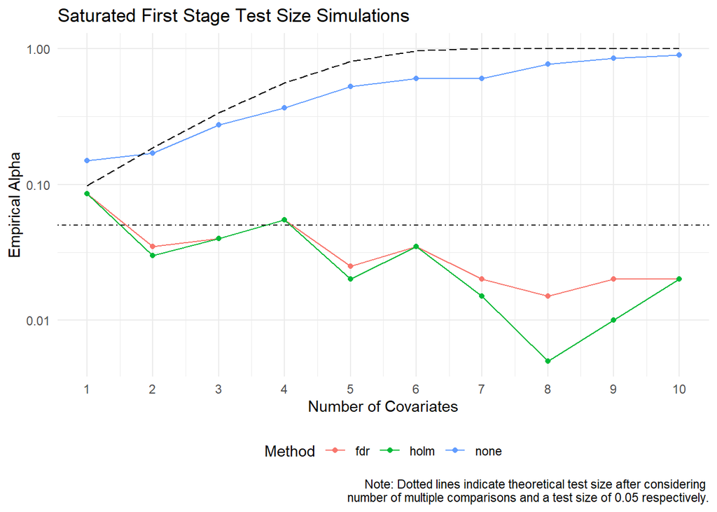

```r
tidy_adj_p_cov %>%
    filter(method == "none" | method == "fdr" | method == "holm") %>%
ggplot(aes(y = empirical_alpha,
           x = n_cov,
           colour = method)) +
  geom_line() +
  geom_point() +
  scale_y_log10() +
  theme_minimal() +
  geom_line(aes(y = theoretical_alpha), linetype = "longdash", colour = "black") +
  geom_hline(yintercept = 0.05, linetype = 4)  +
  labs(x = "Number of Covariates",
       y = "Empirical Alpha",
       title = "Saturated First Stage Test Size Simulations",
       caption = "Note: Dotted lines indicate theoretical test size after considering \n number of multiple comparisons and a test size of 0.05 respectively.",
       colour = "Method") +
  theme(legend.position = "bottom") +
  scale_x_continuous(breaks = 1:10)
```

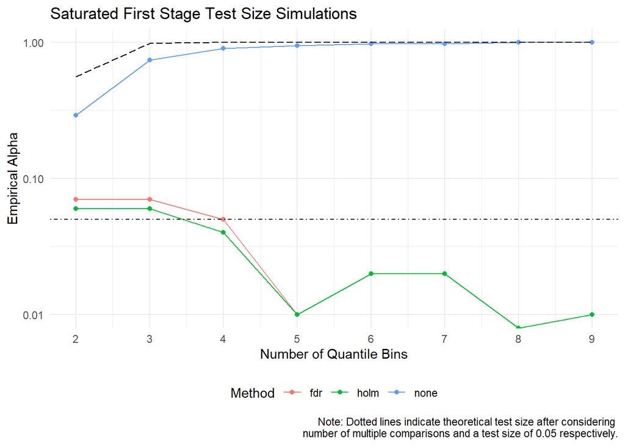

```r
tidy_adj_p_tiles %>%
    filter(method == "none" | method == "fdr" | method == "holm") %>%
  ggplot(aes(y = empirical_alpha,
             x = n_tiles,
             colour = method)) +
  geom_line() +
  geom_point() +
  scale_y_log10() +
  theme_minimal() +
  geom_line(aes(y = theoretical_alpha), linetype = "longdash", colour = "black") +
  geom_hline(yintercept = 0.05, linetype = 4) +
  labs(x = "Number of Quantile Bins",
       y = "Empirical Alpha",
       title = "Saturated First Stage Test Size Simulations",
       caption = "Note: Dotted lines indicate theoretical test size after considering \n number of multiple comparisons and a test size of 0.05 respectively.",
       colour = "Method") +
  theme(legend.position = "bottom") +
  scale_x_continuous(breaks = 2:9)
```

In conclusion, simulation results clearly show saturated first stage test size $\geq \alpha$ without any additional control procedures. In the remainder of the essay $p$-values are adjusted for the number of comparisons made.

### Honest Causal Forest

Controlling test size in the honest causal forest setting is a little more challenging. A priori it’s not immediately obvious how many comparisons to adjust for. Tentative evidence from simulations suggest that adjustments for $N^2$ comparisons is adequate however I offer no formal proof of this.

```r
source("simulations/code/rf_size_sim.R")
```

The honest causal forest test faces a far greater multiple comparison problem - test size simulations using 2000 simulated datasets with 1000 observations each reject the null hypothesis in almost every dataset with unadjusted $p$-values. The family wise error rate is only controlled at a level less than or equal to $\alpha$ when adjusting for one million ($1000^2$) comparisons.[^3]

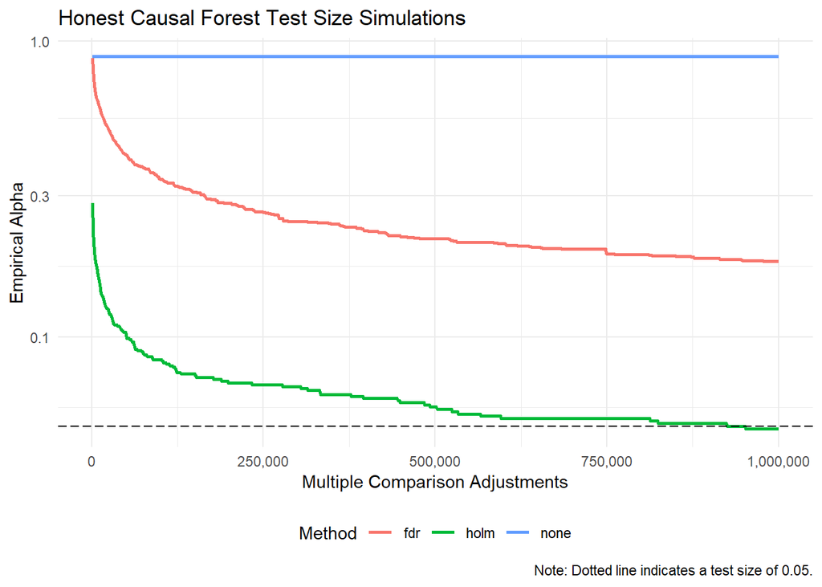

```r
holm_adjusted_pvals <- seq(from = 1000, to = 1000000, by = 1000) %>%
  map_df(~p.adjust_df(n = ., method = c("none", "fdr", "holm"), p = rf_size_sims$pval_one_neg) %>%
           mutate(n = .x))

holm_adjustment_summary <- holm_adjusted_pvals %>%
  gather(method, pval, -n) %>%
  mutate(reject_null = ifelse(pval < 0.05, TRUE, FALSE)) %>%
  group_by(method, n) %>%
  summarise(empirical_alpha = sum(ifelse(reject_null, 1, 0)) / n())


holm_adjustment_summary %>%
  ggplot(aes(x = n, y = empirical_alpha, colour = method)) +
  geom_line(size = 1) +
  geom_hline(yintercept = 0.05, linetype = "longdash") +
  scale_y_log10() +
  theme_minimal() +
  labs(x = "Multiple Comparison Adjustments",
       y = "Empirical Alpha",
       title = "Honest Causal Forest Test Size Simulations",
       caption = "Note: Dotted line indicates a test size of 0.05.",
       colour = "Method") +
  theme(legend.position = "bottom") +
  scale_x_continuous(label = comma)
```

Now that test size has been explored in both tests, I move onto test power. Given the large adjustments that must be made in both tests it’s reasonable to worry that test power is particularly low - fortunately, simulations show that this only seems to be true in smaller datasets of around 1000 observations.

## Power Simulations

Test power is the ability of a test to correctly reject a null hypothesis. Classical frequentist testing in econometrics usually sets a desired test size (control of the type I error rate) and uses the most powerful test possible with little thought to test size-power trade-off. To measure test power I generate 2000 draws of a simulated dataset, with 1,000, 5,000 and 10,000 observations respectively. To assess power under a range of data generating processes (DGPs) I use three specifications:

### Subgroup Heterogeneity

First, a conventional setting where treatment heterogeneity is only generated at the subgroup level through the use of interaction terms:

$$D_i = \pi_0 + \pi_{1}Z_i + \sum_{k=1}^4 (\gamma_{k}x_{ki} + \delta_{k}(Z_i \times x_{ki})) + \epsilon_i; \ \epsilon_i \sim N(0, 5^2) \\
\pi_1, \gamma_k, \delta_k \sim U(-1, 1)$$
Here covariates are drawn from a multivariate normal with mean $0$ and variance $\Sigma$.[^4] Z is a binary instrument drawn from a Bernoulli distribution with probability one half.

Model parameters are drawn from a uniform distribution with support from -1 to 1. Rather than explicitly generating a positive main effect and defiers at given proportions I let the random draws determine the simulated data properties and discretise the data into 1% defier bins - this gives good coverage of the defier space up to concentrations of 25%. However, past 25% the simulations become particularly uninformative - there’s very few simulation draws in this region, typically less than 1% of all draws due to the nature of the DGP used. Furthermore, the distinction between defier and complier becomes murky when approaching an even split in the population - if this situation arises in practice it’s questionable whether LATE really is the estimator of interest to a researcher.

In this context we’d expect the saturated first stage to perform best since it exactly matches the data generating process whilst the honest causal forest should still manage to infer the underlying heterogeneous treatment effects created by the interaction terms.

### Individual Heterogeneity

Second, a truly heterogeneous setting where the same DGP as above is used but now individual treatment effects, $\pi_{1i}, \gamma_{ki}, \delta_{ki}$ are sampled from a multivariate normal distribution centred around a population treatment effect with means $\Pi_k, \Gamma_k, \Delta_{k}$ and variance $I_k$.

$$D_i = \pi_0 + \pi_{1i}Z_i + \sum_{k=1}^4 (\gamma_{ki}x_{ki} + \delta_{ki}(Z_i \times x_{ki})) + \epsilon_i; \ \epsilon_i \sim N(0, 5^2) \\
\pi_{1i} \sim N(\Pi_1, 1); \ \gamma_{ki} \sim N(\Gamma_{k}, I_k); \ \delta \sim N(\Delta_k, I_k) \\
\Pi_1, \Gamma_k, \Delta_k \sim U(-1, 1)$$

This true heterogeneity should pose a challenge for both tests since the saturated first stage model can only estimate an average treatment effect at the subgroup level and individual level heterogeneity is fully independent of covariates so cannot be accurately inferred by the honest causal forest.

### Non-Linear Heterogeneity

$$D_i = \pi_0 + \pi_{1}(x_{1i})Z_i + \sum_{k=1}^4 (\gamma_{k}x_{ki}) + \epsilon_i; \ \epsilon_i \sim N(0, 5^2) \\
\pi_{1}( \cdot) = max(\cdot, -1.5); \ \ \gamma_k \sim N(0, I_k)$$

Finally, I create defiers through a non-linear data generating process similar to the canonical case used by the authors of the honest causal forest R package (Athey, Tibshirani, and Wager 2016). In this setting $\pi_{1}$, the instrument main effect, is a function of the first covariate. That is, $\pi_{1}(x_{1i}) = max(x_{1i}, -1.5)$, the remaining covariates in this case are simply homogeneous treatment effects drawn from a standard normal - crucially, there are *no* interaction terms present in the true DGP. In this setting we’d expect the honest causal forest to outperform its conventional cousin, the saturated first stage test.

## Simulation Results

Since I generate highly non-linear and distinct DGPs it’s hard to maintain uniform defier coverage and defier “strength” - the magnitude of a defiers’ treatment effect in comparison to a complier - between contexts. Therefore, comparisons across DGPs should be made sparingly and with caution. Comparisons within simulation settings between tests is the focus of this essay.

```r
source("simulations/code/subgroup_sim.R")
simulations_power_subgroup <- bind_rows(
                                       simulations_power_subgroup_small,
                                       simulations_power_subgroup_medium,
                                        simulations_power_subgroup_large
                                       ) %>%
    mutate(N = factor(N, levels = c("Small", "Medium", "Large")),
           n_comparisons = ifelse(model == "Saturated First Stage", 2^4, NA),
           n_comparisons = ifelse(model == "Forest" & N == "Small", 1000^2, n_comparisons),
           n_comparisons = ifelse(model == "Forest" & N == "Medium",
                                  5000^2,
                                  n_comparisons),
           n_comparisons = ifelse(model == "Forest" & N == "Large",
                                  10000^2,
                                  n_comparisons))



rm(simulations_power_subgroup_small,
   simulations_power_subgroup_medium,
   simulations_power_subgroup_large)


simulations_power_subgroup <- simulations_power_subgroup %>%
  rowwise() %>%
  mutate(pval_holm = p.adjust(pval_defier, method = "holm", n = n_comparisons)) %>%
  ungroup()
```

Throughout the essay I use an inverted y-axis when displaying $p$-values - the reason for this is two-fold. First, when considering thousands of $p$-values, as we are in this essay, it’s common to use a negative log transform, popularised by biostatistics and genome studies. Displaying the “most significant” $p$-values at the very top of the visualisation makes better use of the space in a figure - we care less about the null hypothesis $p$-values we’re least able to reject. Secondly, inverting the y-axis maintains consistency when we move to the negative log transform rather than switching between visualisation paradigms.

### Subgroup Heterogeneity

The random forest method, too, performs surprisingly well - even better than the saturated first stage test it would seem at first glance. Both tests improve substantially as sample size increases and as defier proportion increases as we’d expect.

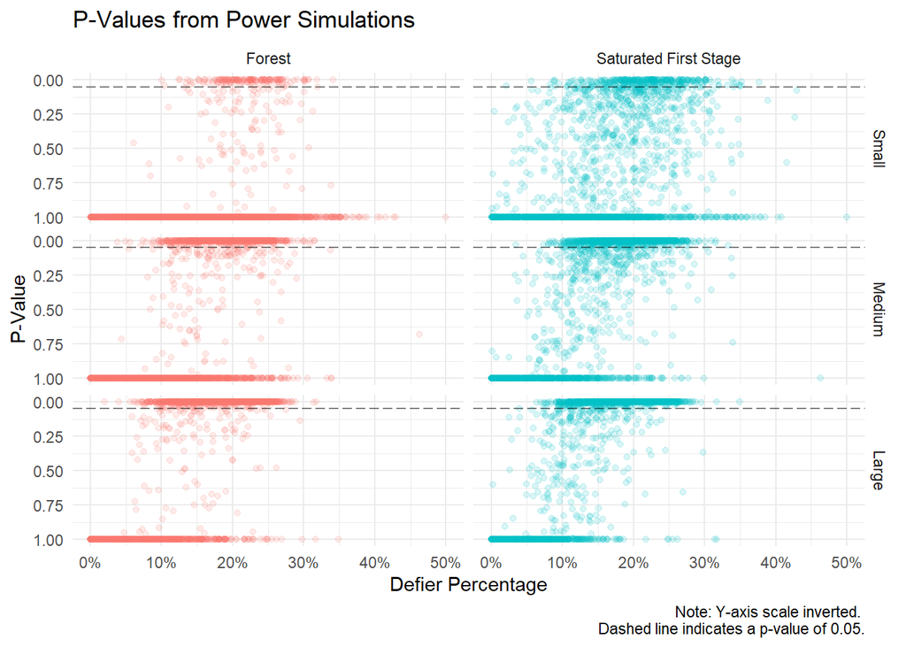

```r
simulations_power_subgroup %>%
  filter(pct_defiers_true > 0) %>%
  ggplot(aes(x = pct_defiers_true,
             y = pval_holm,
             colour = model)) +
  geom_point(alpha = 0.15) +
  geom_hline(yintercept = 0.05,
             linetype = "longdash",
             alpha = 0.5) +
  scale_y_reverse() +
  scale_x_continuous(labels = scales::percent_format(accuracy = 1)) +
  facet_grid(N~model) +
  labs(x = "Defier Percentage",
       y = "P-Value",
       caption = "Note: Y-axis scale inverted. \n Dashed line indicates a p-value of 0.05.",
       title = "P-Values from Power Simulations") +
  theme_minimal() +
  guides(colour = "none")
```

The difference between the figure using a linear scale and $p$-values displayed on a log scale, below, clearly motivates the use of a log transform. $p$-values from the medium and larger dataset are orders of magnitude smaller than the $p$-values from the smallest dataset as we’d expect.

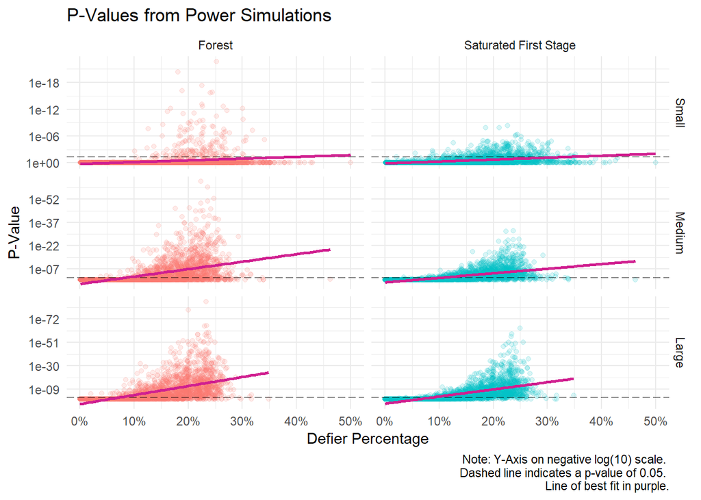

```r
simulations_power_subgroup %>%
  unite(mod_N, model, N, remove = FALSE) %>%
  filter(pct_defiers_true > 0) %>%
  ggplot(aes(x = pct_defiers_true,
             y = pval_holm,
             group = mod_N)) +
  geom_point(alpha = 0.15, aes(colour = model)) +
  geom_hline(yintercept = 0.05,
             linetype = "longdash",
             alpha = 0.5) +
  scale_y_continuous(trans = negative_log_trans(10)) +
  scale_x_continuous(labels = scales::percent_format(accuracy = 1)) +
  guides(colour = "none") +
  theme_minimal() +
  facet_grid(N~model,
             scales = "free_y") +
  labs(x = "Defier Percentage",
       y = "P-Value",
       caption = "Note: Y-Axis on negative log(10) scale. \n Dashed line indicates a p-value of 0.05. \n Line of best fit in purple.",
       title = "P-Values from Power Simulations") +
  geom_smooth(method = lm,
              se = FALSE,
              alpha = 0.2,
              colour = "violetred")
```

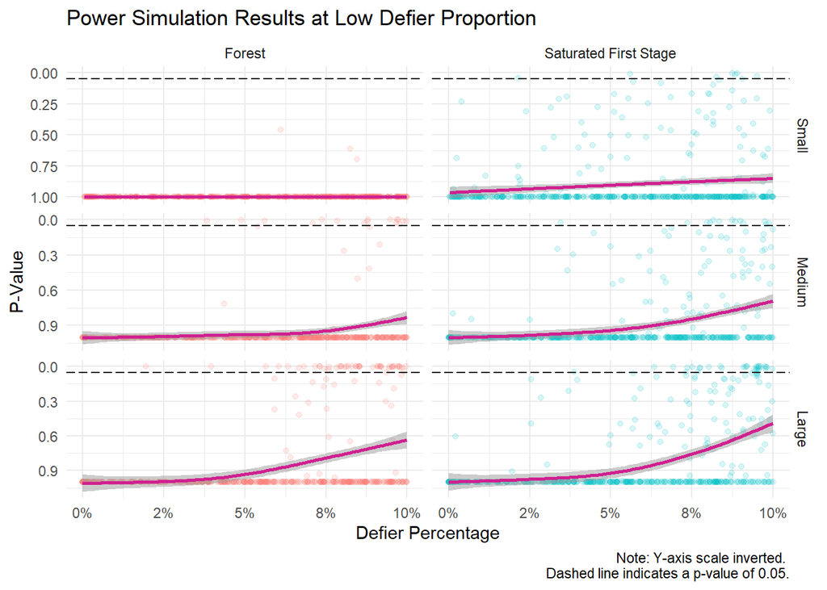

```r
simulations_power_subgroup %>%
  filter(pct_defiers_true > 0) %>%
  ggplot(aes(x = pct_defiers_true,
             y = pval_holm,
             colour = model)) +
  geom_point(alpha = 0.15,
             aes(colour = model)) +
  geom_hline(yintercept = 0.05, linetype = "longdash") +
  scale_y_reverse() +
  geom_smooth(se = TRUE,
              colour = "violetred",
              alpha = 0.5) +
  scale_x_continuous(limits = c(0, 0.1),
                     labels = scales::percent_format(accuracy = 1)) +
  theme_minimal() +
  facet_grid(N~model, scales = "free_y") +
  guides(colour = "none") +
  labs(x = "Defier Percentage",
       y = "P-Value",
       title = "Power Simulation Results at Low Defier Proportion",
       caption = "Note: Y-axis scale inverted. \n Dashed line indicates a p-value of 0.05.")
```

One concern may be that whilst the tests are capable of detecting defiers, this may be driven by defier activity in the tails. That is, the tests may work but only because of extremely “defiant” defiers since we only consider the most extreme defier in each sample. Fortunately, we can turn to each test’s respective model predictions and compare estimated number of defiers against the actual number of defiers present in the data. The results are reassuring, as the number of defiers grow the number of predicted defiers grows too.

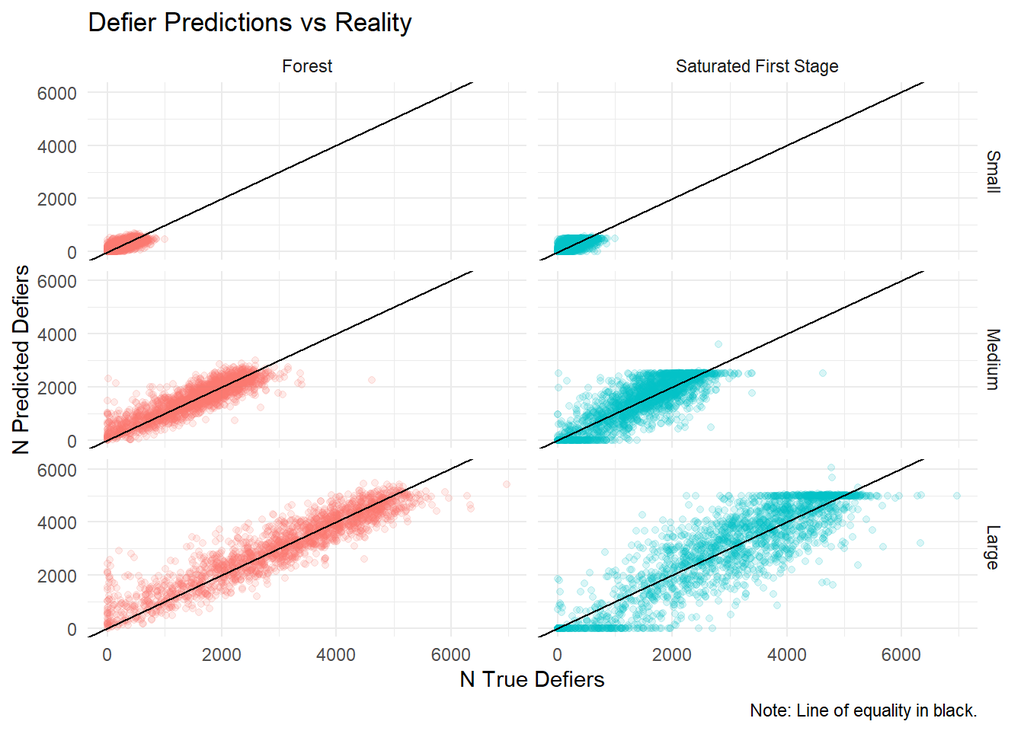

```r
simulations_power_subgroup %>%
  ggplot(aes(x = n_defiers_true,
             y = n_defiers_estimated,
             colour = model)) +
  geom_point(alpha = 0.15) +
  facet_grid(N~model) +
  geom_abline(slope = 1,
              intercept = 0) +
  theme_minimal() +
  guides(colour = "none") +
  labs(x = "N True Defiers",
       y = "N Predicted Defiers",
       title = "Defier Predictions vs Reality",
       caption = "Note: Line of equality in black.")
```

Moving from power comparisons to mean $p$-value comparisons makes it easier to estimate the underlying uncertainty by calculating the standard error of the mean in each percentile bin - the reduction in uncertainty is stark when moving from the smaller to larger datasets.

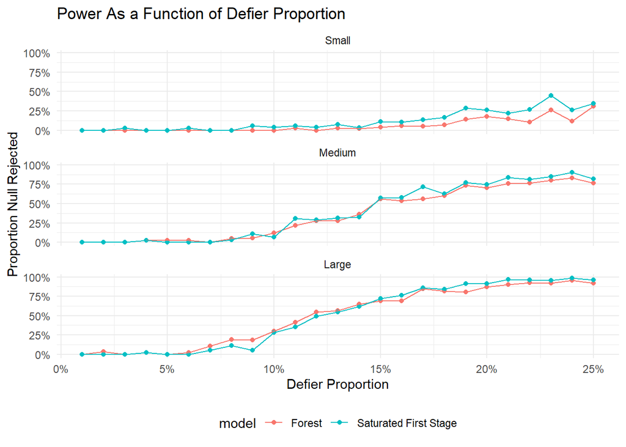

```r
sim_bin <- simulations_power_subgroup %>%
  mutate(gr=cut(pct_defiers_true, labels = FALSE, breaks= seq(0, 1, by = 0.01))/100) %>%
  group_by(model,
           N,
           gr) %>%
  mutate(n= n()) %>%
  arrange(gr) %>%
  mutate(n_rejected = ifelse(pval_holm < 0.05, 1, 0)) %>%
  mutate(pct_rejected = sum(n_rejected)/n)

sim_bin_summ <- simulations_power_subgroup %>%
  group_by(model,
           N,
           gr=cut(pct_defiers_true,label = FALSE, breaks= seq(0, 1, by = 0.01))) %>%
  mutate(n= n()) %>%
  arrange(as.numeric(gr)) %>%
  mutate(n_rejected = ifelse(pval_defier < 0.05, 1, 0)) %>%
  summarise(pct_rejected = mean(n_rejected),
            sd_rejected = sd(n_rejected),
            n = unique(n),
            mean_true_defier = mean(pct_defiers_true))


sim_bin %>%
  na.omit() %>%
  filter(pct_defiers_true < 0.25) %>%
  ggplot(aes(x = gr, y = pct_rejected, colour = model, group = model)) +
  geom_point() +
  geom_line() +
  theme_minimal() +
  scale_y_continuous(labels = scales::percent_format(accuracy = 1)) +
  guides(size = "none")  +
  theme(legend.position = "bottom") +
  labs(y = "Proportion Null Rejected",
       x = "Defier Proportion",
       title = "Power As a Function of Defier Proportion") +
  facet_wrap(~N, ncol = 1) +
  scale_x_continuous(breaks = seq(from = 0, 1, 0.05),
                     labels = scales::percent_format(accuracy = 1))
```

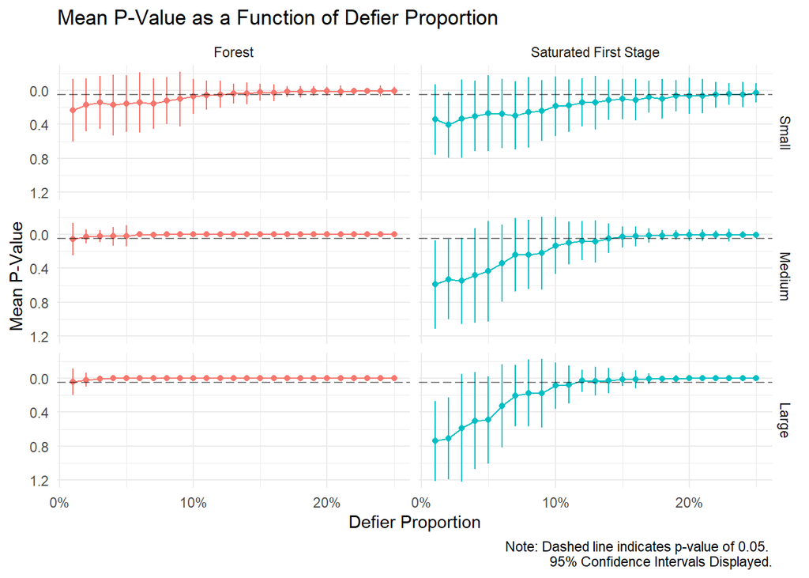

```r
sim_bin %>%
  na.omit() %>%
  filter(pct_defiers_true < 0.25) %>%
  summarise(m_pval = mean(pval_defier),
         sd_pval = sd(pval_defier)) %>%
  ggplot(aes(x = gr, y = m_pval, colour = model, group = model)) +
  geom_point() +
  geom_line() +
  geom_linerange(aes(x = gr,
                     ymin = m_pval - 1.96*sd_pval,
                     ymax = m_pval + 1.96*sd_pval)) +
  theme_minimal() +
  guides(size = "none",
         colour = "none") +
  facet_grid(N~model) +
    labs(y = "Mean P-Value",
       x = "Defier Proportion",
       caption = "Note: Dashed line indicates p-value of 0.05. \n 95% Confidence Intervals Displayed.",
       title = "Mean P-Value as a Function of Defier Proportion") +
  geom_hline(yintercept = 0.05,
             linetype = "longdash",
             alpha = 0.5) +
  scale_y_reverse() +
  scale_x_continuous(breaks = seq(from = 0,
                                  to = 1,
                                  0.1),
                     labels = scales::percent_format(accuracy = 1))
```

```r
# sim_bin_summ %>%
#   ggplot(aes(x = gr, y = pct_rejected, colour = model, group = model)) +
#   geom_point() +
#   geom_line() +
#   geom_linerange(aes(x = gr,
#                      ymin = pct_rejected - 1.96*sd_rejected,
#                      ymax = pct_rejected + 1.96*sd_rejected)) +
#   theme_minimal() +
#   scale_y_continuous(labels = scales::percent_format(accuracy = 1)) +
#   guides(size = "none",
#          colour = "none") +
#   facet_grid(N~model) +
#     labs(y = "Proportion Null Rejected",
#        x = "Defier Proportion",
#        caption = "Note: Point size indicates number of draws in bin. \n 95% Confidence Intervals Displayed.",
#        title = "Power As a Function of Defier Proportion")
```

### Individual Heterogeneity

Again, there seems to be large dispersion in estimated $p$-values even under similar data generating processes and defier coverage. As expected, $p$-values fall (i.e. move up the $y$-axis using a negative log scale.) as defier coverage increases.

```r
source("simulations/code/hetero_sim.R")

simulations_power_indiv <- bind_rows(
                                    simulations_power_hetero_small,
                                    simulations_power_hetero_medium,
                                    simulations_power_hetero_large
                                    ) %>%
  as_tibble() %>%
    mutate(N = factor(N, levels = c("Small", "Medium", "Large")),
           n_comparisons = ifelse(model == "Saturated First Stage", 2^4, NA),
           n_comparisons = ifelse(model == "Forest" & N == "Small",
                                  1000^2,
                                  n_comparisons),
           n_comparisons = ifelse(model == "Forest" & N == "Medium",
                                  5000^2,
                                  n_comparisons),
           n_comparisons = ifelse(model == "Forest" & N == "Large",
                                  10000^2,
                                  n_comparisons))


rm(simulations_power_hetero_small,
   simulations_power_hetero_medium,
   simulations_power_hetero_large)

simulations_power_indiv <- simulations_power_indiv %>%
  rowwise() %>%
  mutate(pval_holm = p.adjust(pval_defier, method = "holm", n = n_comparisons)) %>%
  ungroup()
```

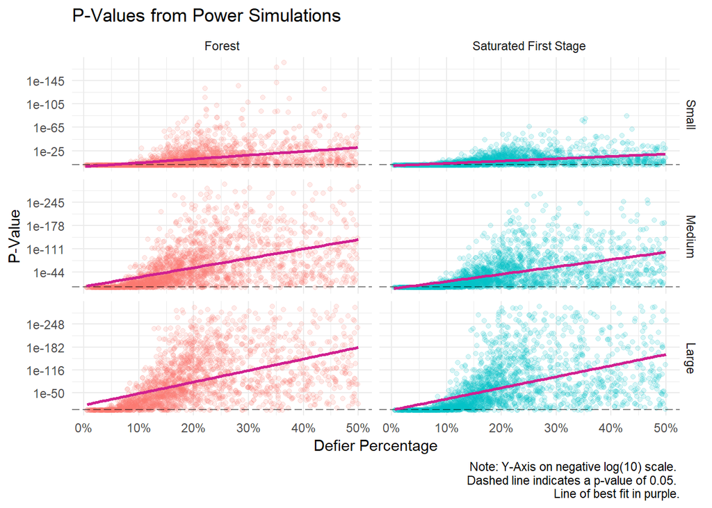

```r
simulations_power_indiv %>%
  unite(mod_N, model, N, remove = FALSE) %>%
  filter(pct_defiers_true > 0) %>%
  filter(pval_holm > 1e-300) %>%
  ggplot(aes(x = pct_defiers_true,
             y = pval_holm,
             group = mod_N)) +
  geom_point(alpha = 0.15, aes(colour = model)) +
  geom_hline(yintercept = 0.05,
             linetype = "longdash",
             alpha = 0.5) +
  scale_y_continuous(trans = negative_log_trans(10)) +
  scale_x_continuous(labels = scales::percent_format(accuracy = 1)) +
  guides(colour = "none") +
  theme_minimal() +
  facet_grid(N~model, scales = "free_y") +
  labs(x = "Defier Percentage",
       y = "P-Value",
       caption = "Note: Y-Axis on negative log(10) scale. \n Dashed line indicates a p-value of 0.05. \n Line of best fit in purple.",
       title = "P-Values from Power Simulations") +
  geom_smooth(method = lm,
              se = FALSE,
              alpha = 0.2,
              colour = "violetred")
```

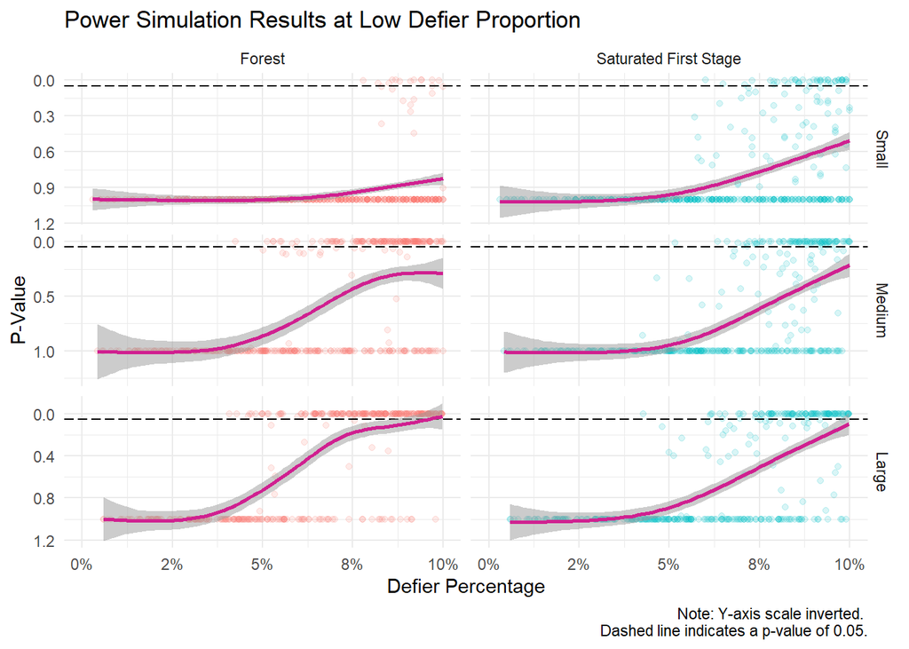

```r
simulations_power_indiv %>%
  filter(pct_defiers_true > 0) %>%
  ggplot(aes(x = pct_defiers_true,
             y = pval_holm,
             colour = model)) +
  geom_point(alpha = 0.15,
             aes(colour = model)) +
  geom_hline(yintercept = 0.05, linetype = "longdash") +
  scale_y_reverse() +
  geom_smooth(se = TRUE,
              colour = "violetred",
              alpha = 0.5) +
  scale_x_continuous(limits = c(0, 0.1), labels = scales::percent_format(accuracy = 1)) +
  theme_minimal() +
  facet_grid(N~model, scales = "free_y") +
  guides(colour = "none") +
  labs(x = "Defier Percentage",
       y = "P-Value",
       title = "Power Simulation Results at Low Defier Proportion",
       caption = "Note: Y-axis scale inverted. \n Dashed line indicates a p-value of 0.05.")
```

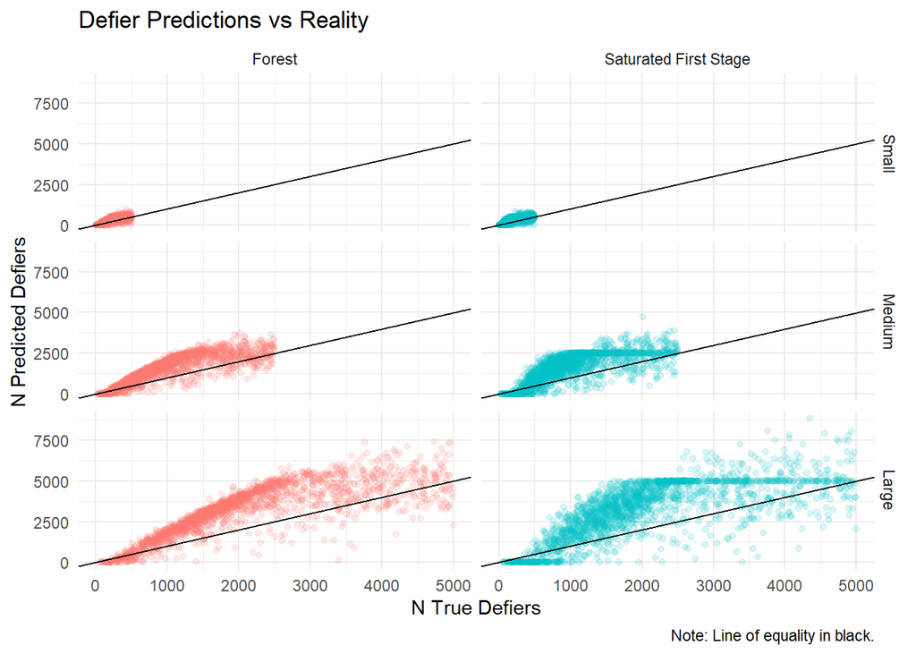

```r
simulations_power_indiv %>%
  ggplot(aes(x = n_defiers_true,
             y = n_defiers_estimated,
             colour = model)) +
  geom_point(alpha = 0.15) +
  facet_grid(N~model) +
  geom_abline(slope = 1, intercept = 0) +
  theme_minimal() +
  guides(colour = "none") +
  labs(x = "N True Defiers",
       y = "N Predicted Defiers",
       title = "Defier Predictions vs Reality",
       caption = "Note: Line of equality in black.")
```

Despite misgivings concerning test performance under model misspecification both tests still perform strongly with almost perfect identification at 15% defier proportions in the larger datasets. The apparent paradox between a noisier DGP and better test performance highlights why comparisons between tests across DGPs should be undertaken with caution. Power is a function of defier magnitude; defier proportion and the size of the error term but only defier proportion and error variance is held constant across specifications.

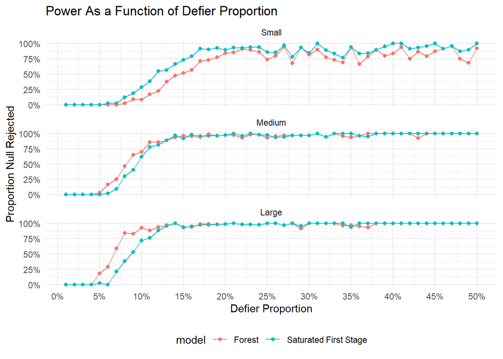

```r
sim_bin_indiv <- simulations_power_indiv %>%
  mutate(gr=cut(pct_defiers_true, labels = FALSE, breaks= seq(0, 1, by = 0.01))/100) %>%
  group_by(model,
           N,
           gr) %>%
  mutate(n= n()) %>%
  arrange(gr) %>%
  mutate(n_rejected = ifelse(pval_holm < 0.05, 1, 0)) %>%
  mutate(pct_rejected = sum(n_rejected)/n)

sim_bin_indiv %>%
  na.omit() %>%
  ggplot(aes(x = gr,
             y = pct_rejected,
             colour = model,
             group = model)) +
  geom_point() +
  geom_line() +
  theme_minimal() +
  scale_y_continuous(labels = scales::percent_format(accuracy = 1)) +
  guides(size = "none")  +
  theme(legend.position = "bottom") +
  labs(y = "Proportion Null Rejected",
       x = "Defier Proportion",
       title = "Power As a Function of Defier Proportion") +
  facet_wrap(~N, ncol = 1) +
  scale_x_continuous(breaks = seq(from = 0, 1, 0.05),
                     labels = scales::percent_format(accuracy = 1))
```

Overall it seems both tests maintain reasonable levels of power under model mispecification issues although the saturated first stage suffers a little more - again this in part, could help explain the observed divergence between the two tests later.

### Non-Linear Heterogeneity

```r
source("simulations/code/non_linear_sim.R")
simulations_power_nl <- bind_rows(
                                  simulations_power_non_linear_small,
                                  simulations_power_non_linear_medium,
                                  simulations_power_non_linear_large
                                  ) %>%
  as_tibble() %>%
    mutate(N = factor(N, levels = c("Small", "Medium", "Large")))

rm(simulations_power_non_linear_small,
   simulations_power_non_linear_medium,
   simulations_power_non_linear_large)
```

Using the non-linear data generating process the magnitude of $p$-values has increased significantly i.e. $p$-values are much less small compared to the subgroup and individually heterogeneous cases. Now the smallest $p$-values are around $1 \times e^{-35}$ as opposed to $1 \times e^{-250}$ as seen above. Interestingly, the honest causal forest seems to produce far smaller $p$-values at given defier proportions than the honest causal forest. The honest causal forest test enjoys a comparative advantage at picking up non-linearities at even the tiniest sign of defiance.

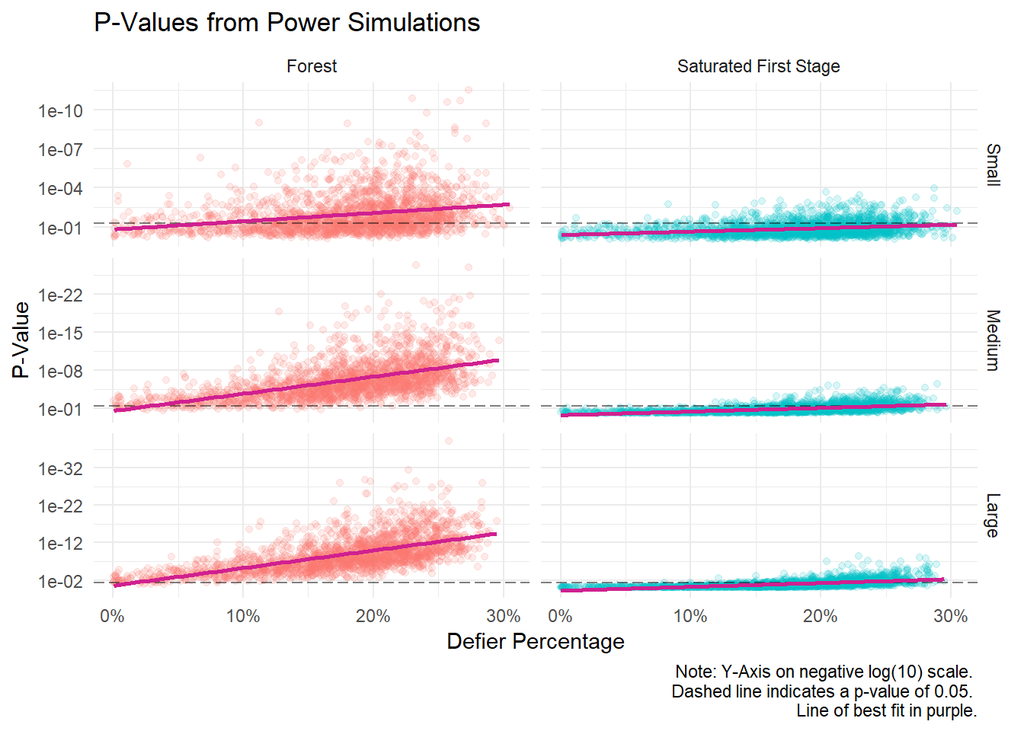

```r
simulations_power_nl %>%
  unite(mod_N, model, N, remove = FALSE) %>%
  filter(pct_defiers_true > 0) %>%
  filter(pval_defier > 1e-300) %>%
  ggplot(aes(x = pct_defiers_true,
             y = pval_defier,
             group = mod_N)) +
  geom_point(alpha = 0.15, aes(colour = model)) +
  geom_hline(yintercept = 0.05,
             linetype = "longdash",
             alpha = 0.5) +
  scale_y_continuous(trans = negative_log_trans(10)) +
  scale_x_continuous(labels = scales::percent_format(accuracy = 1)) +
  guides(colour = "none") +
  theme_minimal() +
  facet_grid(N~model,
             scales = "free_y") +
  labs(x = "Defier Percentage",
       y = "P-Value",
       caption = "Note: Y-Axis on negative log(10) scale. \n Dashed line indicates a p-value of 0.05. \n Line of best fit in purple.",
       title = "P-Values from Power Simulations") +
  geom_smooth(method = lm,
              se = FALSE,
              alpha = 0.2,
              colour = "violetred")
```

In a non-linear context it seems that saturated first stage struggles to detect defiance in all three of the datasets considered whereas honest causal forest only struggles in the very smallest dataset.

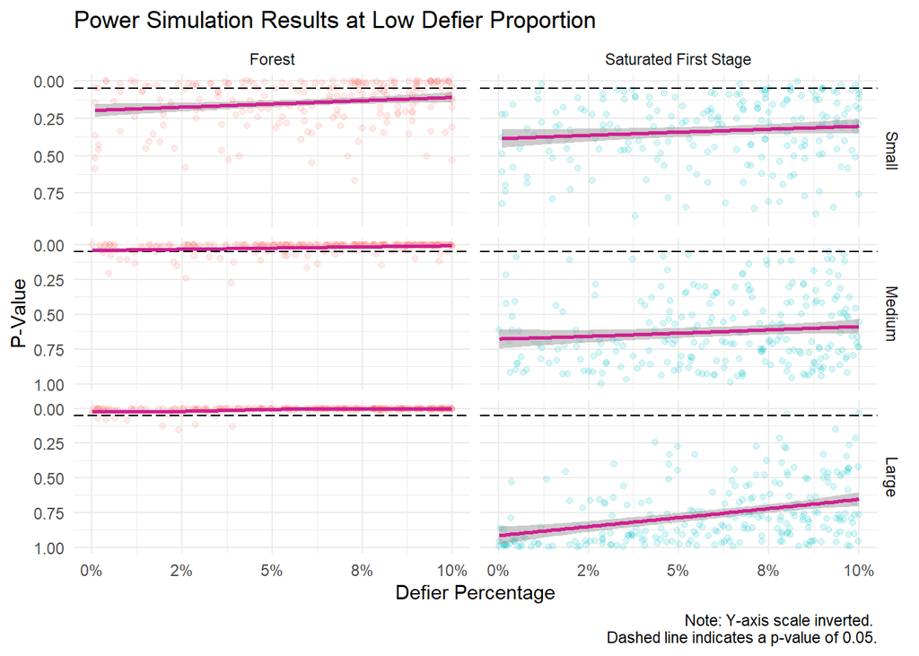

```r
simulations_power_nl %>%
  filter(pct_defiers_true > 0) %>%
  ggplot(aes(x = pct_defiers_true,
             y = pval_defier,
             colour = model)) +
  geom_point(alpha = 0.15,
             aes(colour = model)) +
  geom_hline(yintercept = 0.05,
             linetype = "longdash") +
  scale_y_reverse() +
  geom_smooth(se = TRUE,
              colour = "violetred",
              alpha = 0.5) +
  scale_x_continuous(limits = c(0, 0.1),
                     labels = scales::percent_format(accuracy = 1)) +
  theme_minimal() +
  facet_grid(N~model, scales = "free_y") +
  guides(colour = "none") +
  labs(x = "Defier Percentage",
       y = "P-Value",
       title = "Power Simulation Results at Low Defier Proportion",
       caption = "Note: Y-axis scale inverted. \n Dashed line indicates a p-value of 0.05.")
```

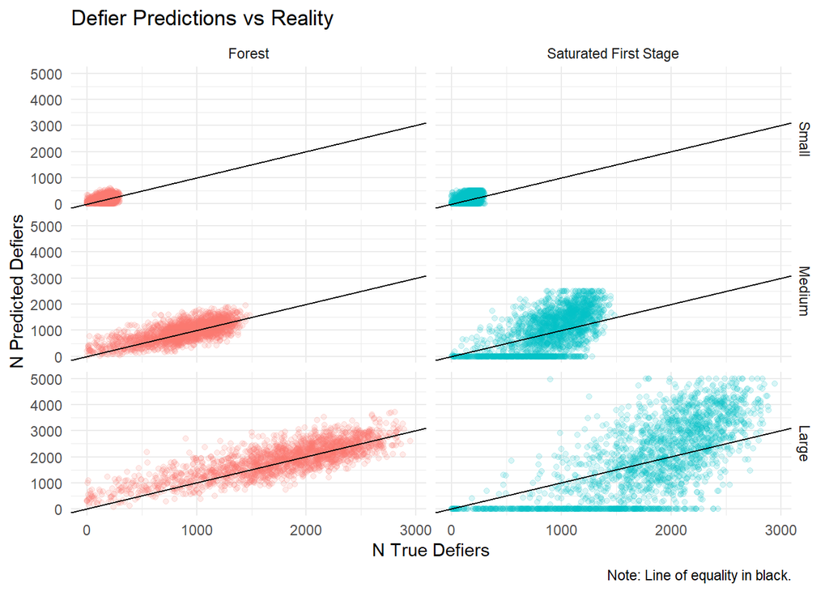

```r
simulations_power_nl %>%
  ggplot(aes(x = n_defiers_true,
             y = n_defiers_estimated,
             colour = model)) +
  geom_point(alpha = 0.15) +
  facet_grid(N~model) +
  geom_abline(slope = 1,
              intercept = 0) +
  theme_minimal() +
  guides(colour = "none") +
  labs(x = "N True Defiers",
       y = "N Predicted Defiers",
       title = "Defier Predictions vs Reality",
       caption = "Note: Line of equality in black.")
```

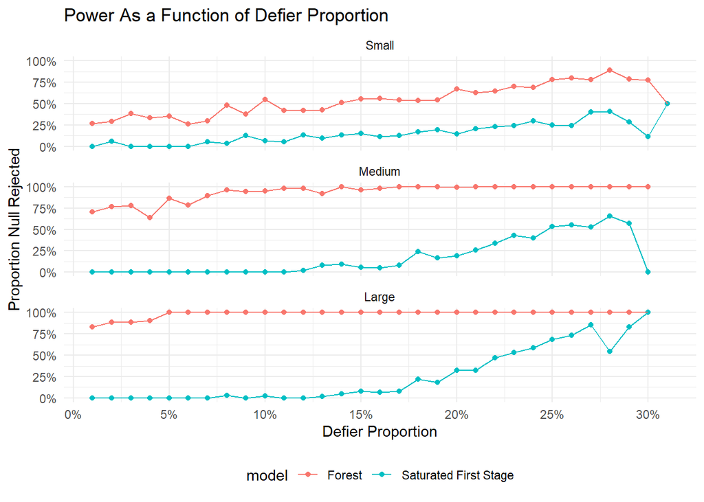

```r
sim_bin_nl <- simulations_power_nl %>%
  mutate(gr=cut(pct_defiers_true,
                labels = FALSE,
                breaks= seq(0, 1, by = 0.01))/100) %>%
  group_by(model,
           N,
           gr) %>%
  mutate(n= n()) %>%
  arrange(gr) %>%
  mutate(n_rejected = ifelse(pval_defier < 0.05, 1, 0)) %>%
  mutate(pct_rejected = sum(n_rejected)/n)



sim_bin_nl %>%
  na.omit() %>%
  filter(pct_defiers_true < 0.35) %>%
  ggplot(aes(x = gr,
             y = pct_rejected,
             colour = model,
             group = model)) +
  geom_point() +
  geom_line() +
  theme_minimal() +
  scale_y_continuous(labels = scales::percent_format(accuracy = 1)) +
  guides(size = "none")  +
  theme(legend.position = "bottom") +
  labs(y = "Proportion Null Rejected",
       x = "Defier Proportion",
       title = "Power As a Function of Defier Proportion") +
  facet_wrap(~N, ncol = 1) +
  scale_x_continuous(breaks = seq(from = 0, 1, 0.05),
                     labels = scales::percent_format(accuracy = 1))
```

Overall, both methods fare well under a range of data generating processes. Each test has individual strengths and weaknesses suggesting a thorough investigation of defiance should include both.

# Empirical Results

```r
## Angrist and Evans 1998

#### 1990 Census Data

df_90 <- read_sas("Angrist and Evans 90.sas7bdat")


# Cleaning data according to Angrist and Evans SAS replication codes:

clean_angrist_evans_data <- function(dataset){
  df_clean <- dataset %>%
    filter((AGEM <= 35) & (AGEM >= 21)) %>%
    filter(KIDCOUNT >= 2) %>%
    filter(AGE2NDK >= 1) %>%
    filter(AAGE == "0" & AAGE2ND == "0" & ASEX == "0" & ASEX2ND == "0") %>%
    mutate(SEXK = as.numeric(SEXK),
           SEX2NDK = as.numeric(SEX2NDK),
           WEEK89D = as.numeric(WEEK89D),
           WEEK89M = as.numeric(WEEK89M),
           FERTIL = as.numeric(FERTIL)) %>%
    mutate(fertdif = as.numeric(KIDCOUNT) - (FERTIL - 1),
           agefstm = as.numeric(AGEM) - as.numeric(AGEK)) %>%
    filter(agefstm >= 15) %>%
    filter(PWGTM1 > 0) %>%
    mutate(samesex = (SEXK == SEX2NDK),
           morekids = (KIDCOUNT > 2)) %>%
    rename_all(tolower)
  return(df_clean)
}
df_90_clean <- df_90 %>%
  clean_angrist_evans_data()
rm(df_90)

#### 1980 Census Data



df_80 <- read_sas("Angrist and Evans 80.sas7bdat")

df_80_clean <- df_80 %>%
    mutate(SEXK = as.numeric(SEXK),
         SEX2ND = as.numeric(SEX2ND),
         WEEKSD = as.numeric(WEEKSD),
         WEEKSM = as.numeric(WEEKSM),
         YOBM = as.numeric(YOBM),
         AGEQK = as.numeric(AGEQK),
         YOBD = 80 - as.numeric(AGED),
         YOBD = ifelse(QTRBTHD == 0, YOBD, YOBD - 1)) %>%
  mutate(samesex = (SEXK == SEX2ND),
         morekids = (KIDCOUNT > 2),
         ageqm = 4*(80-YOBM) - as.numeric(QTRBTHM) - 1,
         ageqd = 4*(80 - YOBD) - as.numeric(QTRBKID),
         agefstm = round((ageqm-AGEQK)/4),
         agefstd = round((ageqd - AGEQK)/4),
         QTRMAR = as.numeric(QTRMAR),
         QTRBTHM = as.numeric(QTRBTHM),
         AGEMAR = as.numeric(AGEMAR),
         QTRBKID = as.numeric(QTRBKID),
         FERTIL = as.numeric(FERT)
         ) %>%
  rename_all(tolower)




df_80_filtered <- df_80_clean %>%
  filter((agem <= 35) & (agem >= 21)) %>%
  filter(kidcount >= 2) %>%
  filter(ageq2nd > 4) %>%
  filter(agefstm >= 15) %>%
  filter(agefstd >= 15 | is.na(agefstd)) %>%
  filter(asex == 0 &
         aage == 0 &
         aqtrbrth == 0 &
         asex2nd == 0 &
         aage2nd == 0 &
         aqtrbrth == 0)



df_80_filtered_two <- df_80_filtered %>%
  mutate(
         qtrmar = ifelse(qtrmar > 0, qtrmar - 1, qtrmar),
         yom = ifelse(qtrbthm <= qtrmar, yobm + agemar, yobm+agemar+1),
         dom_q = yom + (qtrmar/4),
         do1b_q = yobk + qtrbkid/4,
         illegit = ifelse(dom_q - do1b_q > 0, 1, 0)
         ) %>%
  mutate(
         msample = ifelse(
           !is.na(aged) &
           timesmar == 1 &
           marital == 0 &
           illegit == 0 &
           agefstd >= 15 &
           agefstm >= 15,
           1, 0)
         ) %>%
  filter(msample == 1)

######################

df_80_subset <- df_80_filtered_two %>%
  rename(kid_age = agek,
         m_age = agem,
         d_age = aged) %>%
  select(-starts_with("a")) %>%
  mutate_at(c("racek",
              "birthplk",
              "schoolk",
              "state",
              "spanishm",
              "spanishd",
              "poverty"), factor) %>%
  mutate_if(is.character, as.numeric)



df_80_final <- df_80_subset %>%
  mutate(boy1st = (sexk == 0),
         boy2nd = (sex2nd == 0),
         boys2 = (sexk == 0) & (sex2nd == 0),
         girls2 = (sexk == 1) & (sex2nd == 1),
         samesex = boys2 | girls2,
         morekids = kidcount > 2,
         black_m = (racem == 2),
         hisp_m = (racem == 12),
         white_m = (racem == 01),
         other_race_m = 1 - black_m - hisp_m - white_m,
         black_d = (raced == 2),
         hisp_d = (raced == 12),
         white_d = (raced == 1),
         other_race_d = 1 - black_d - hisp_d - white_d,
         worked_m = (weeksm > 0),
         worked_d = (weeksd > 0),
         income_m = 2.099173554*(income1m + pmax(0, income2m)),
         income_d = (income1d + pmax(0, income2d)),
         fam_inc = pmax(faminc*2.099173554, 1),
         nonmoi = fam_inc - income1m*2.099173554,
         nonmomil = log(pmax(1, nonmoi)))
rm(df_80,
   df_80_clean,
   df_80_filtered,
   df_80_filtered_two,
   df_80_subset)



## data transformations
transform_clean_angrist_evans <- function(dataset) {
  transformed_df <- dataset %>%
    rename(
      kid_age = agek,
      kid2_age = age2ndk,
      m_age = agem,
      d_age = aged
    ) %>%
    select(-starts_with("a")) %>%
    mutate_at(c(
      "racek",
      "birthplk",
      "schoolk",
      "state",
      "hispm",
      "hispd",
      "poverty",
      "pobm",
      "hispd",
      "pobd",
      "hispk"
    ), factor) %>%
    mutate_if(is.character, as.numeric) %>%
    mutate(
      boy1st = (sexk == 0),
      boy2nd = (sex2ndk == 0),
      boys2 = (sexk == 0) & (sex2ndk == 0),
      girls2 = (sexk == 1) & (sex2ndk == 1),
      samesex = boys2 | girls2,
      morekids = kidcount > 2,
      black_m = (racem == 2),
      hisp_m = (racem == 12),
      white_m = (racem == 01),
      other_race_m = 1 - black_m - hisp_m - white_m,
      black_d = (raced == 2),
      hisp_d = (raced == 12),
      white_d = (raced == 1),
      other_race_d = 1 - black_d - hisp_d - white_d,
      worked_m = (week89m > 0),
      worked_d = (week89d > 0)
    )

  return(transformed_df)
}

df_90_subset <- df_90_clean %>%
  transform_clean_angrist_evans()




df_90_final <- df_90_subset %>%
  mutate(
         income_m = 1.2883*(incomem1 + pmax(0, incomem2)),
         income_d = (incomed1 + pmax(0, incomed2)),
         fam_inc = pmax(faminc*1.2883, 1),
         nonmoi = fam_inc - incomem1*1.2883,
         nonmomil = log(pmax(1, nonmoi))
  )

rm(df_90_clean, df_90_subset)




## Maimonides Rule


# Mention somewhere HAC instead of moulton factor adjustment - only makes a large difference in the discontinuity sample.

#### Cleaning Grade 5
clean_maimonides_data <- function(dataset){
  clean_df <- dataset %>%
    mutate(
      avgverb = ifelse(avgverb > 100, avgverb - 100, avgverb),
      avgmath = ifelse(avgmath > 100, avgmath - 100, avgmath),
      func1 = c_size/(as.integer((c_size-1)/40)+1),
      func2 = cohsize/(as.integer(cohsize/40)+1),
      avgverb = ifelse(verbsize == 0, NA, avgverb),
      passverb = ifelse(verbsize == 0, NA, passverb),
      avgmath = ifelse(mathsize == 0, NA, avgmath),
      passmath = ifelse(mathsize == 0, NA, avgmath),
      disc = (c_size >= 36 & c_size <= 45) |
             (c_size >= 76 & c_size <= 85) |
             (c_size >= 116 & c_size <= 125),
      all = 1,
      c_size_squared = (c_size^2)/100,
      trend = ifelse(c_size >= 0 & c_size <= 40, c_size, NA),
      trend = ifelse(c_size >= 41 & c_size <= 80, 20 + (c_size/2), trend),
      trend = ifelse(c_size >= 81 & c_size <= 120, (100/3) + (c_size/3), trend),
      trend = ifelse(c_size >= 121 & c_size <= 160, (130/3) + (c_size/4), trend)
    ) %>%
    filter(
      classize > 1 & classize < 45 & c_size > 5
    ) %>%
    filter(
      c_leom == 1 & c_pik < 3
    )
  return(clean_df)

}

df_final5_cleaned <- read_dta("Angrist and Lavy Grade 5.dta") %>%
  clean_maimonides_data()





#### Cleaning Grade 4
df_final4_cleaned <- read_dta("Angrist and Lavy Grade 4.dta") %>%
  clean_maimonides_data()
```

# Saturated First Stage Test

## Angrist and Evans

Angrist and Evans (1998) explores the effect of fertility on household labour supply - they instrument fertility, the number of children a household has, with a same-sex variable that takes the value 1 if a household has two children of identical sex and 0 otherwise. The paper’s findings suggest that having an additional child reduces a mother’s labour supply somewhat substantially.

In this context, a complier is a couple that are more likely to have an additional child if their current children have the same-sex - there is a well documented gender mix preference amongst parents. However, for the LATE estimate to be valid there cannot be any couples that are induced not to have an additional child if their current children are the same-sex.

A plausible explanation for potential defiance could be the presence of economies of scale when raising same-sex children that are potentially lost when considering a third child of ex-ante unknown gender. In this case, couples may be induced to stop having children if both their current off-spring are of the same gender.

```r
AE_data_80 <- df_80_final %>%
  select(
    samesex,
    morekids,
    black_m,
    hisp_m,
    other_race_m,
    black_d,
    hisp_d,
    other_race_d,
    gradem,
    graded,
    m_age,
    d_age
  ) %>%
  na.omit()

AE_data_90 <- df_90_final %>%
  select(samesex,
         morekids,
         black_m,
         hisp_m,
         other_race_m,
         black_d,
         hisp_d,
         other_race_d,
         yearschm,
         yearschd,
         m_age,
         d_age,
         pwgtm1,
         pwgtd1) %>%
  na.omit()





first_stage_interactions_80 <- AE_data_80 %>%
  run_first_stage_interactions_fast(dataset = .,
                                    dependent_variable = "morekids",
                                    instrument = "samesex",
                                    vcov_func = vcovHC,
                                    n_tiles = 3) %>%
  mutate(dataset = "1980") %>%
  select(dydx_instrument, SE_dydx_instrument, pval_one_neg, dataset, dydx_lo, dydx_hi, t_stat, n_comparisons, pval_neg_holm)
first_stage_interactions_90 <- AE_data_90 %>%
  run_first_stage_interactions_fast(dataset = .,
                                   dependent_variable = "morekids",
                                   instrument = "samesex",
                                   vcov_func = vcovHC,
                                   n_tiles = 3) %>%
  mutate(dataset = "1990") %>%
  select(dydx_instrument, SE_dydx_instrument, pval_one_neg, dataset, dydx_lo, dydx_hi, t_stat, n_comparisons, pval_neg_holm)

first_stage_interactions_AE <- bind_rows(
  first_stage_interactions_90,
  first_stage_interactions_80)

## Number of corrections (theoretical)= 2^6  * 3^4 = 5184 (I think)

## Adjusting confidence intervals for multiple comparisons

first_stage_interactions_AE <- first_stage_interactions_AE %>%
  mutate(dydx_lo_a = dydx_instrument - SE_dydx_instrument*qt(1-(0.05/2)/n_comparisons, df = n()/2),
         dydx_hi_a = dydx_instrument +  SE_dydx_instrument*qt(1-(0.05/2)/n_comparisons, df = n()/2))
```

Angrist and Evans (1998) run a first stage regression of the form:
$$morekids_i = \alpha + \beta samesex_i + \gamma X_i + u_i$$
where $X_i$ is a vector of controls including *age*; *age at first birth*; indicators for *Boy 1st*, *Boy 2nd*, *Black*, *Hispanic*, and *Other race*. In addition to this, I include controls for parental years of schooling and parental weight.

The distribution of estimated partial effects is plotted below. Instrument partial effects seem to be particularly homogeneous; there’s very little dispersion around mean partial effects of 0.067, 0.068 respectively. Promisingly, results below zero appear to be nonexistent.

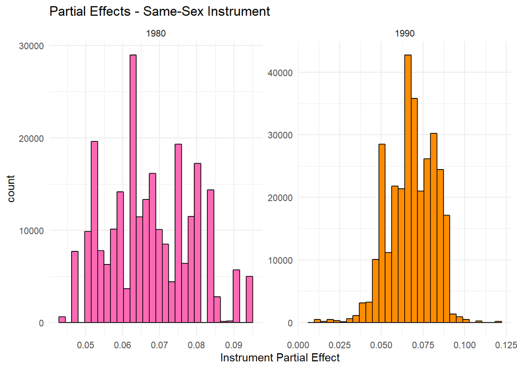

```r
colour_pair <- c("hotpink", "darkorange")

first_stage_interactions_AE %>%
  ggplot(aes(x = dydx_instrument, fill = dataset)) +
  geom_histogram(colour = "black") +
  facet_wrap(~dataset, scales = "free") +
  theme_minimal() +
  guides(fill = "none") +
  scale_fill_manual(values = colour_pair) +
  labs(x = "Instrument Partial Effect",
       title = "Partial Effects - Same-Sex Instrument")
```

Ranking instrument partial effects and corresponding confidence intervals shows two things. First, all the partial effects estimated are positive. Second, effects are estimated with large differences in precision. This makes sense, if there’s one subgroup with less data or less precisely estimated effects this will show up in the uncertainty of partial effect estimates.

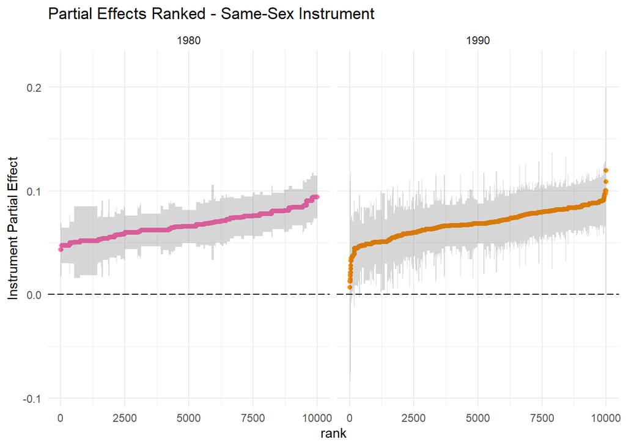

```r
first_stage_interactions_AE %>%
  group_by(dataset) %>%
  sample_n(10000) %>%
  arrange(dydx_instrument) %>%
  mutate(rank = row_number()) %>%
  ggplot(aes(x = rank, y = dydx_instrument, ymin = dydx_lo_a, ymax = dydx_hi_a)) +
  geom_point(aes(colour = dataset)) +
  geom_ribbon(alpha = 0.2) +
  theme_minimal() +
  facet_wrap(~dataset, scales = "free_x") +
  geom_hline(yintercept = 0, linetype = "longdash") +
  guides(colour = "none") +
  scale_colour_manual(values = colour_pair) +
  labs(y = "Instrument Partial Effect",
       title = "Partial Effects Ranked - Same-Sex Instrument")
```

The histogram of $p$-values corresponding to the one-sided null hypothesis of no defiers is rather uninformative and only displayed here as further motivation for the negative log transform of $p$-value quantiles used for the remainder of the essay. Notably, most $p$-values are very close to 1 - as we’d expect when the vast majority of partial effects are positive and significant.

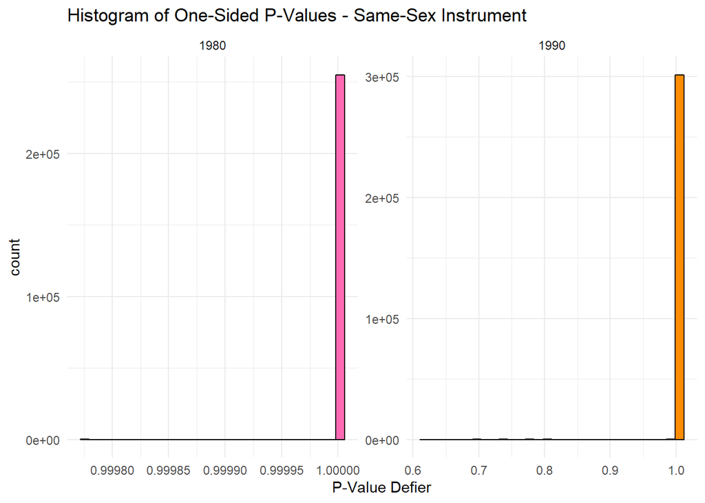

```r
first_stage_interactions_AE %>%
  ggplot(aes(x = pval_one_neg, fill = dataset)) +
  geom_histogram(colour = "black") +
  facet_wrap(~dataset, scales = "free") +
  theme_minimal() +
  scale_fill_manual(values = colour_pair) +
  guides(fill = "none") +
  labs(x = "P-Value Defier",
       title = "Histogram of One-Sided P-Values - Same-Sex Instrument")
```

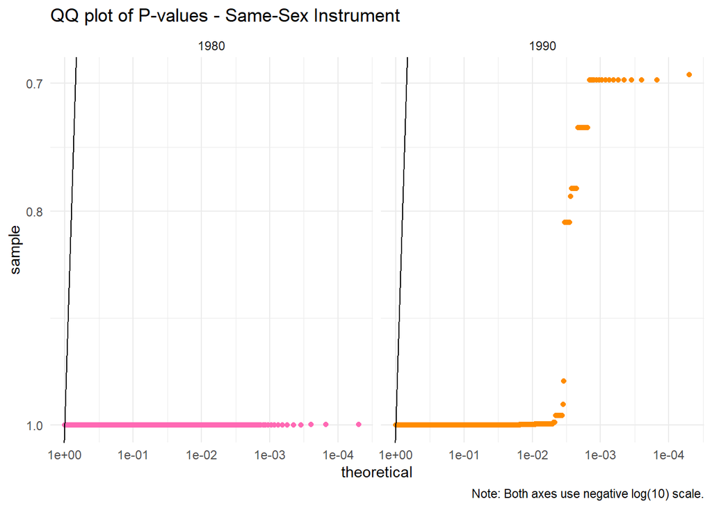

```r
first_stage_interactions_AE %>%
  group_by(dataset) %>%
  sample_n(10000) %>%
  ggplot(aes(sample = pval_one_neg, colour = dataset)) +
  stat_qq(distribution = qunif) +
  geom_abline(intercept = 0, slope = 1) +
  theme_minimal() +
  scale_x_continuous(trans=negative_log_trans(10)) +
  scale_y_continuous(trans=negative_log_trans(10)) +
  labs(title = "QQ plot of P-values - Same-Sex Instrument",
       caption = "Note: Both axes use negative log(10) scale.") +
  facet_wrap(~dataset) +
  guides(colour = "none") +
  scale_colour_manual(values = colour_pair)
```

Above is the quantile-quantile plot of unadjusted $p$-values. The plot displays the sample versus theoretical quantiles of partial effect $p$-values using a uniform distribution. Under a two-sided null hypothesis $p$-values will be uniformly distributed and therefore the empirical CDF will be a straight line from 0 to 1 with slope 1.

This method of visualisation is popular in Genome Wide Association Studies (GWAS) when displaying thousands of $p$-values. Typically analysts are interested in the hypotheses corresponding to small $p$-values (i.e. statistically significant $p$-values) and therefore both axes are inverted on a log-log scale. This means the “most significant” $p$-values will appear at the top right of the plots.

$p$-values hugging the line of equality indicate evidence in favour of the null hypothesis. We’d expect a strong first stage to exhibit near horizontal movement to the right - there are many more large $p$-values in the sample than we’d expect theoretically under the null. Therefore, in this essay evidence of defiance would appear as a horizontal line, due to strong first stages in all papers considered, followed by curving back towards or even past the line of equality.

This tool is useful for two reasons - it displays the strength of the first stage but also evidence of defiance in a scale invariant manner. In Angrist and Evans’ paper we see both examples to a degree. In the 1980 sample there’s a strong first stage with no evidence of defiance. The 1990 sample exhibits a little curve back because some partial effects are smaller and closer to 0 than the others, but no evidence of actual defiance - the smallest $p$-values are far from reasonable levels of statistical significance.

## Maimonides’ Rule

Lavy and Angrist (1999) use Maimonides’ rule, which dictates that maximum class size should be 40 students, as an instrument for actual class size in a fuzzy regression discontinuity design exploring the effect of class size on test scores in English and maths. Their first stage takes the following form:

$$class\ size_i = \alpha + \beta predicted\ class\ size_i + \gamma_1 enrollment_i + \gamma_2 enrollment^2_i + \gamma_3 pct\ disadvantaged_i + u_i$$
where predicted class size is the class size according to Maimonides’ rule. Due to the difficulties of accurately identifying interaction effects with limited data I choose to use the full sample (parametric fuzzy RDD) rather than the discontinuity sample with only approximately 400 observations.

In the context of Angrist and Lavy’s research design, defiance would require that the predicted class size fall, due to Maimonides’ essentially arbitrary cut-off, would lead to an increase in class size rather than a decrease. Perhaps upon exceeding the cut off a school principal decides that class sizes’ are already breaking Maimonides’ rule therefore more children might as well be added to a class to economise on resources.

```r
first_stage_interactions_maim_5 <-  df_final5_cleaned %>%
    select(classize,
         tipuach,
         c_size,
         func1) %>%
  run_first_stage_interactions_fast(dataset = .,
                                    dependent_variable = "classize",
                                    instrument = "func1",
                                    vcov_func = vcovCL,
                                    cluster = df_final5_cleaned$classid,
                                    n_tiles = 3) %>%
  mutate(dataset = "Fifth Grade") %>%
  select(dydx_instrument, SE_dydx_instrument, pval_one_neg, dataset, dydx_lo, dydx_hi, t_stat, pval_neg_holm, n_comparisons)

first_stage_interactions_maim_4 <- df_final4_cleaned %>%
  select(classize,
         tipuach,
         c_size,
         func1) %>%
  run_first_stage_interactions_fast(dataset = .,
                                   dependent_variable = "classize",
                                   instrument = "func1",
                                   vcov_func = sandwich::vcovCL,
                                   cluster = df_final4_cleaned$classid,
                                   n_tiles = 3) %>%
  mutate(dataset = "Fourth Grade") %>%
  select(dydx_instrument, SE_dydx_instrument, pval_one_neg, dataset, dydx_lo, dydx_hi, t_stat, pval_neg_holm, n_comparisons)

first_stage_interactions_maimonides <- bind_rows(first_stage_interactions_maim_5, first_stage_interactions_maim_4)


# N comparisons = 3^2 = 9

first_stage_interactions_maimonides <- first_stage_interactions_maimonides %>%
    mutate(dydx_lo_a = dydx_instrument - SE_dydx_instrument*qt(1-(0.05/2)/n_comparisons, df = n()/2),
         dydx_hi_a = dydx_instrument +  SE_dydx_instrument*qt(1-(0.05/2)/n_comparisons, df = n()/2))
```

The distribution of instrument partial effects using Maimonides’ rule appear to be definitive; there’s no evidence of defiers in either fourth or fifth grade classes. Ranking the instrument partial effects leads to very similar conclusions - in fact, there are no estimated defiers in either dataset. There are less partial effects estimated using Angrist and Lavy’s dataset since there are fewer covariates available which leads to sparsity of estimated effects and discrete jumps plotted below.

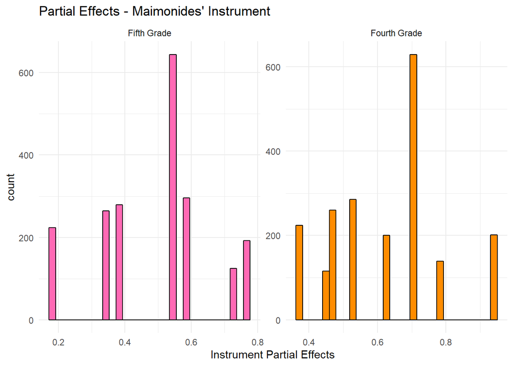

```r
first_stage_interactions_maimonides %>%
  ggplot(aes(x = dydx_instrument, fill = dataset)) +
  geom_histogram(colour = "black") +
  facet_wrap(~dataset, scales = "free") +
  theme_minimal() +
  guides(fill = "none") +
  scale_fill_manual(values = colour_pair) +
  labs(x = "Instrument Partial Effects",
       title = "Partial Effects - Maimonides' Instrument")
```

```r
# first_stage_interactions_maimonides %>%
#   ggplot(aes(x = pval_one_neg, fill = dataset)) +
#   geom_histogram(colour="black") +
#   facet_wrap(~dataset, scales = "free") +
#   guides(fill = "none") +
#   theme_minimal() +
#   labs(title = "P-Values - Maimonides' Instrument",
#        x = "P-Value") +
#   scale_fill_manual(values = colour_pair)
```

The quantile-quantile plot is horizontal throughout, again, indicative of a strong first stage with no evidence of defiers.

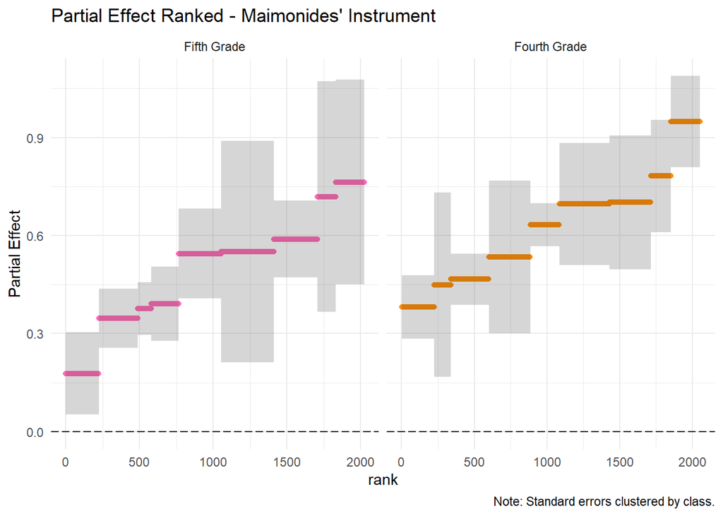

```r
first_stage_interactions_maimonides %>%
  group_by(dataset) %>%
  arrange(dydx_instrument) %>%
  mutate(rank = row_number()) %>%
  ggplot(aes(x = rank, y = dydx_instrument, ymin = dydx_lo_a, ymax = dydx_hi_a)) +
  geom_point(aes(colour = dataset)) +
  geom_ribbon(alpha = 0.2) +
  theme_minimal() +
  facet_wrap(~dataset, scales = "free_x") +
  geom_hline(yintercept = 0, linetype = "longdash") +
  labs(y = "Partial Effect",
       title = "Partial Effect Ranked - Maimonides' Instrument",
       caption = "Note: Standard errors clustered by class.") +
  scale_colour_manual(values = colour_pair) +
  guides(colour = "none")
```

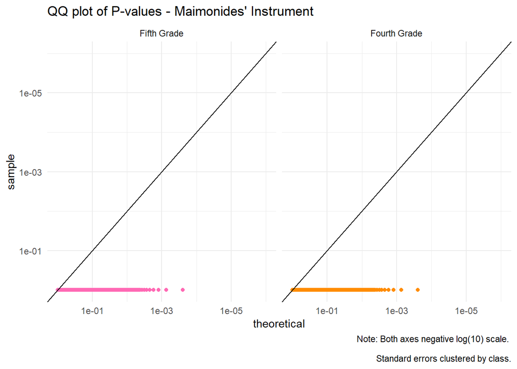

```r
first_stage_interactions_maimonides %>%
  group_by(dataset) %>%
  ggplot(aes(sample = pval_one_neg, colour = dataset)) +
  stat_qq(distribution = qunif) +
  geom_abline(intercept = 0, slope = 1) +
  theme_minimal() +
  scale_x_continuous(trans=negative_log_trans(10), limits = c(1, 0.000001)) +
  scale_y_continuous(trans=negative_log_trans(10), limits = c(1, 0.000001)) +
  labs(title = "QQ plot of P-values - Maimonides' Instrument",
       caption = "Note: Both axes negative log(10) scale.
       \n Standard errors clustered by class.") +
  facet_wrap(~dataset) +
  scale_colour_manual(values = colour_pair) +
  guides(colour = "none")
```

## Autor Dorn Hanson

In Autor, Dorn, and Hanson (2013) the authors investigate the effect of Chinese import competition on US labour markets. The authors use a set of exogenous shocks or *shifts*, which industries are differentially exposed to, to obtain causal estimates. The identification strategy uses a so called “Bartik” or “shift-share” design - instrumenting US imports with changes in Chinese imports by other countries to generate plausibly exogenous temporal variation.

This context is probably the most likely to be susceptible to defiers - it’s plausible that US imports from China won’t react monotonically to changes in third-party Chinese import trends.

```r
df_china <- read_dta("Autor Dorn and Hanson China.dta")
first_stage_interactions_ADH_manu <- df_china %>%
  select(d_sh_empl_mfg,
         d_tradeusch_pw,
         d_tradeotch_pw_lag,
         l_shind_manuf_cbp,
         starts_with("reg"),
         l_sh_popedu_c,
         l_sh_popfborn,
         l_sh_empl_f,
         l_sh_routine33,
         l_task_outsource,
         t2) %>%
  run_first_stage_interactions_fast(dataset = .,
                                    dependent_variable = "d_tradeusch_pw",
                                    instrument = "d_tradeotch_pw_lag",
                                    weights = df_china$timepwt48,
                                    vcov_func = vcovCL,
                                    cluster = df_china$statefip,
                                    n_tiles = 3) %>%
  mutate(dataset = "ADH") %>%
  select(dydx_instrument, SE_dydx_instrument, pval_one_neg,  dataset, dydx_lo, dydx_hi, t_stat, pval_neg_holm, n_comparisons)

# N_comparisons theoretical: 3^7 * 2 = 4374, empirically 571

first_stage_interactions_ADH_manu <- first_stage_interactions_ADH_manu %>%
    mutate(dydx_lo_a = dydx_instrument - SE_dydx_instrument*qt(1-(0.05/2)/n_comparisons, df = n()),
         dydx_hi_a = dydx_instrument +  SE_dydx_instrument*qt(1-(0.05/2)/n_comparisons, df = n()))
```

Autor, Dorn, and Hanson (2013)’s dataset is by far the smallest considered in the essay so simulation results suggest test power will be relatively low and the saturated first stage test should have a comparative advantage over the causal forest test used next. However, even with this caveat the distribution of instrument partial effects seems to display clear presence of defiance.

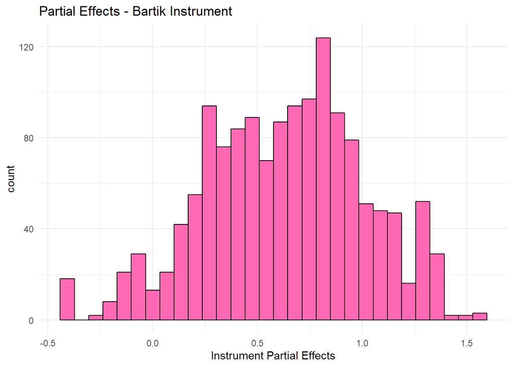

```r
first_stage_interactions_ADH_manu %>%
  ggplot(aes(x = dydx_instrument, fill = dataset)) +
  geom_histogram(colour = "black") +
  guides(fill = "none") +
  scale_fill_manual(values = colour_pair) +
  theme_minimal() +
  labs(x = "Instrument Partial Effects",
       title = "Partial Effects - Bartik Instrument")
```

```r
# first_stage_interactions_ADH_manu %>%
#   ggplot(aes(x = pval_one_neg, fill = dataset)) +
#   geom_histogram(colour = "black") +
#   scale_fill_manual(values = colour_pair) +
#   labs(x = "P-Value",
#        title = "P-Values - Bartik Instrument") +
#   theme_minimal()
```

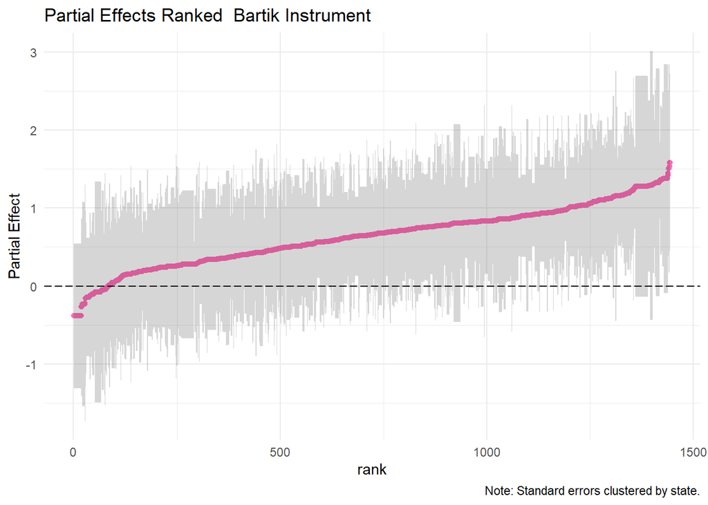

```r
first_stage_interactions_ADH_manu %>%
  arrange(dydx_instrument) %>%
  mutate(rank = row_number()) %>%
  ggplot(aes(x = rank, y = dydx_instrument, ymin = dydx_lo_a, ymax = dydx_hi_a)) +
  geom_point(aes(colour = dataset)) +
  geom_ribbon(alpha = 0.2) +
  theme_minimal() +
  geom_hline(yintercept = 0, linetype = "longdash") +
  scale_colour_manual(values = colour_pair) +
  labs(title = "Partial Effects Ranked  Bartik Instrument",
       y = "Partial Effect",
       caption = "Note: Standard errors clustered by state.") +
  guides(colour = "none")
```

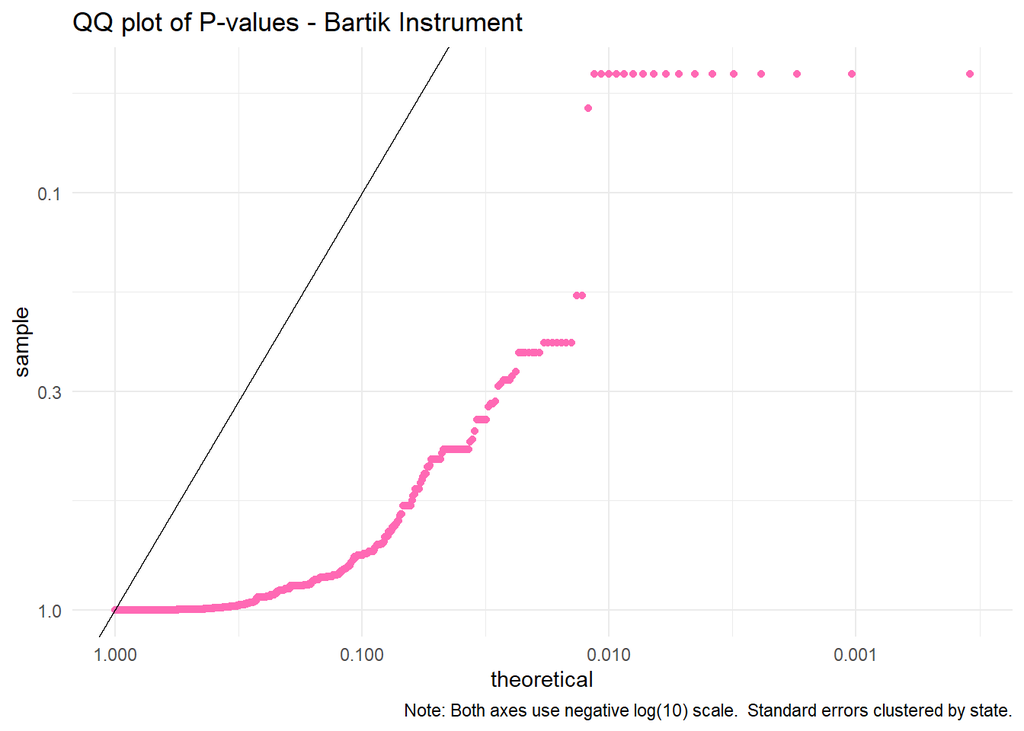

```r
first_stage_interactions_ADH_manu %>%
  ggplot(aes(sample = pval_one_neg, colour = dataset)) +
  stat_qq(distribution = qunif) +
  geom_abline(intercept = 0, slope = 1) +
  theme_minimal() +
  scale_x_continuous(trans=negative_log_trans(10)) +
  scale_y_continuous(trans=negative_log_trans(10)) +
  labs(title = "QQ plot of P-values - Bartik Instrument",
       caption = "Note: Both axes use negative log(10) scale.  Standard errors clustered by state.") +
  guides(colour = "none") +
  scale_colour_manual(values = colour_pair)
```

## Results

```r
first_stage_results <- suppressWarnings(bind_rows(
  first_stage_interactions_AE %>%
    mutate(paper = "Same-Sex"),
  first_stage_interactions_maimonides %>%
    mutate(paper = "Maimonides' Rule"),
  first_stage_interactions_ADH_manu %>%
    mutate(paper = "Shift-Share")
))

## TEST
#
# a <- first_stage_results %>%
#   group_by(paper,
#            dataset) %>%
#   filter(pval_one_neg == min(pval_one_neg))
#
# b <- first_stage_results %>%
#   group_by(paper,
#            dataset) %>%
#   filter(t_stat == min(t_stat))
#
# all_equal(a, b)




first_stage_summary <- first_stage_results %>%
  group_by(paper,
           dataset) %>%
  summarise(estimated_defiers = sum(ifelse(dydx_instrument < 0, 1, 0)),
            n = n(),
            pct_defiers = estimated_defiers / n,
         defier_pval = min(pval_one_neg),
         defier_pval_adjusted = min(pval_neg_holm),
         defier_tstat = min(t_stat)) %>%
  ungroup() %>%
  mutate(dataset = factor(dataset,
                          levels = c("1980",
                                     "1990",
                                     "Fourth Grade",
                                     "Fifth Grade",
                                     "ADH")))

adjusted_p_vals <- first_stage_summary %>%
  filter(paper == "Same-Sex") %>%
  mutate(p_adj = p.adjust(defier_pval_adjusted, "holm")) %>%
  select(p_adj) %>%
  pull() %>%
  round(., 3)
```

In conclusion, the saturated first stage test using the three papers shows similar results. There are no estimated defiers in the first two papers considered and only approximately 6% in Autor, Dorn and Hanson’s paper. Even without any multiple comparison adjustments we cannot reject the null of no defiance in Autor, Dorn and Hanson’s paper with a $p$-value of 0.052. Furthermore, after controlling for multiple comparison adjustments, it’s clear that evidence of defiance is statistically insignificant.

The evidence in favour of the null using Maimonides’ rule and the same-sex instrumental variables strategy is particularly strong - both adjusted and unadjusted $p$-values are particularly large at 1 or 0.611 in the 1990 same-sex sample.

```r
colnames(first_stage_summary) <- c("Paper",
                                   "Dataset",
                                   "Defiers",
                                   "N",
                                   "% Defier",
                                   "P-Value",
                                   "Adjusted P-Value",
                                   "T-Stat")

temp_df <- as_tibble(cbind(nms = names(first_stage_summary), t(first_stage_summary)))


colnames(temp_df) <- temp_df[2, ]

temp_df <- temp_df %>%
  filter(Dataset != "Paper" & Dataset != "Dataset") %>%
  mutate_at(vars(-Dataset),
            as.numeric)

temp_df %>%
  gt(rowname_col = "Dataset")  %>%
  tab_spanner(
    label = "Same-Sex",
    columns = vars(`1980`, `1990`)
  ) %>%
  tab_spanner(
    label = "Maimonides' Rule",
    columns = vars("Fourth Grade", "Fifth Grade")
  ) %>%
  tab_spanner(
    label = "Shift-Share",
    columns = vars("ADH")
  ) %>%
  fmt_number(
    columns = vars(`1990`,
                   `1980`,
                   `Fourth Grade`,
                   `Fifth Grade`,
                   `ADH`),
    decimals = 3,
    drop_trailing_zeros = TRUE
    ) %>%
  fmt_percent(
    columns = vars(`1980`,
                   `1990`,
                   `Fourth Grade`,
                   `Fifth Grade`,
                   `ADH`),
    rows = 3
  ) %>%
  tab_header(
    title = "Saturated First Stage Results"
  )
```

Saturated First Stage Results

|  | Maimonides' Rule |  | Same-Sex |  | Shift-Share |
| --- | --- | --- | --- | --- | --- |
|  | Fifth Grade | Fourth Grade | 1980 | 1990 | ADH |
| Defiers | 0 | 0 | 0 | 0 | 84 |
| N | 2,024 | 2,053 | 255,010 | 302,836 | 1,444 |
| % Defier | 0.00% | 0.00% | 0.00% | 0.00% | 5.82% |
| P-Value | 1 | 1 | 1 | 0.611 | 0.052 |
| Adjusted P-Value | 1 | 1 | 1 | 1 | 1 |
| T-Stat | 3.929 | 4.419 | 3.507 | 0.283 | -1.627 |

```r
rm(temp_df)
```

The $p$-values reported in the table can be interpreted as the probability, under the null of no defiers, of observing a weakly more extreme defier in the sample. Both Angrist and Lavy’s and Autor, Dorn and Hanson’s datasets are relatively small in comparison to the census data used by Angrist and Evans where the evidence in favour of the null seems rather definitive. Overall, it would seem that the saturated first stage test is unable to detect the presence of defiers in the datasets considered.

# Honest Causal Forest Test

## Angrist and Evans

```r
N_obs <- 10000
df_rf_AE_80 <- AE_data_80 %>%
  sample_n(N_obs)

X_matrix_AE_80 <- df_rf_AE_80 %>%
  select(-samesex, -morekids) %>%
  as.matrix()

forest_first_stage_AE_80 <- causal_forest(X = X_matrix_AE_80,
                                    Y = df_rf_AE_80$morekids,
                                    W = df_rf_AE_80$samesex,
                                    num.trees = 4000)
tau_hat_oob_AE_80 <- predict(forest_first_stage_AE_80, estimate.variance = TRUE) %>%
  as_tibble() %>%
  mutate(dataset = "1980")

## Now 90s

df_rf_AE_90 <- AE_data_90 %>%
  sample_n(N_obs)

X_matrix_AE_90 <- df_rf_AE_90 %>%
  select(-samesex, -morekids) %>%
  as.matrix()

forest_first_stage_AE_90 <- causal_forest(X = X_matrix_AE_90,
                                          Y = df_rf_AE_90$morekids,
                                          W = df_rf_AE_80$samesex,
                                          num.trees = 4000)
tau_hat_oob_AE_90 <- predict(forest_first_stage_AE_90, estimate.variance = TRUE) %>%
  as_tibble() %>%
  mutate(dataset = "1990")

tau_hat_oob_AE <- bind_rows(tau_hat_oob_AE_90,
                            tau_hat_oob_AE_80)
```

The estimated heterogeneous instrument effects produce very different results, compared to the saturated test, using Angrist and Evans (1998)’s same-sex data. Whilst comparing instrument partial effects and heterogeneous treatment effects isn’t quite an apples to apples comparison, it’s surprising that the results are so different.

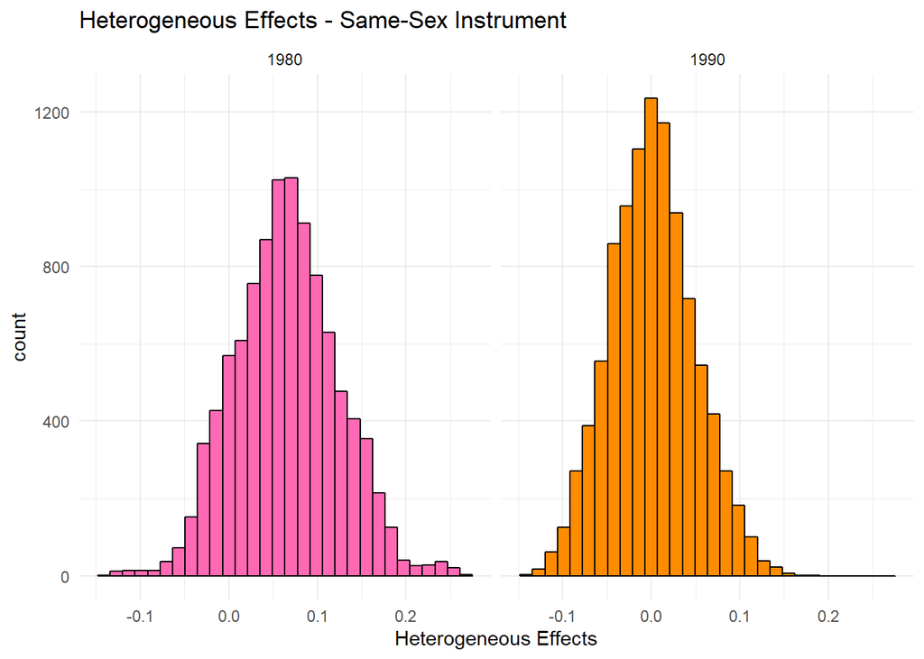

```r
ggplot(tau_hat_oob_AE,
       aes(x = predictions,
           fill = dataset)) +
  geom_histogram(colour = "black") +
  facet_wrap(~dataset) +
  scale_fill_manual(values = colour_pair) +
  labs(x = "Heterogeneous Effects",
       title = "Heterogeneous Effects - Same-Sex Instrument") +
  theme_minimal() +
  guides(fill = "none")
```

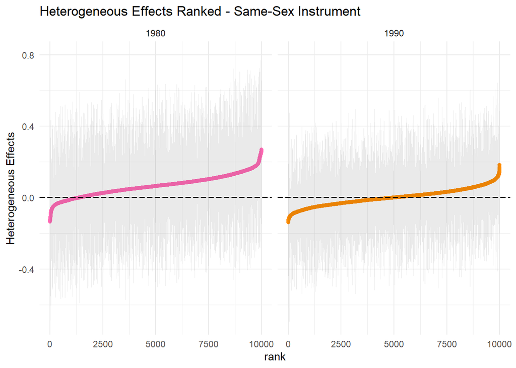

```r
tau_hat_results <- tau_hat_oob_AE %>%
  group_by(dataset) %>%
  arrange(predictions) %>%
  mutate(sigma_hat = sqrt(variance.estimates),
         prediction_lo = predictions - 1.96*sigma_hat,
         prediction_hi = predictions + 1.96*sigma_hat,
         prediction_lo_a = predictions - sigma_hat*qt(1-(0.05/2)/(n()^2), df = n()),
         prediction_hi_a = predictions + sigma_hat*qt(1-(0.05/2)/(n()^2), df = n()),
         t_stat = predictions / sigma_hat,
         critical_value = qt(0.95, N_obs - 13, lower.tail = FALSE),
         pval = pt(t_stat, df = N_obs - 13),
         pval_holm = p.adjust(pval, method = "holm", n = n()^2),
         reject_H0 = ifelse(pval_holm < 0.05, 1, 0),
         rank = row_number())

tau_hat_results %>%
  ggplot(aes(x = rank, y = predictions, ymin = prediction_lo_a, ymax = prediction_hi_a)) +
  geom_point(aes(colour = dataset)) +
  geom_ribbon(alpha = 0.1) +
  theme_minimal() +
  geom_hline(yintercept = 0, linetype = "longdash") +
  facet_wrap(~dataset) +
  scale_colour_manual(values = colour_pair) +
  labs(y = "Heterogeneous Effects",
       title = "Heterogeneous Effects Ranked - Same-Sex Instrument") +
  guides(colour = "none")
```

The QQ plot of $p$-values in the 1990 sample almost perfectly fits the line of equality followed by movement above the line of equality at the 0.01th theoretical quantile. The causal forest method produces slightly different results for the 1980 sample. Here there’s little evidence of the horizontal CDF we’ve grown to expect and limited evidence of defiers, in stark contrast to the 1990 sample.

Such a large difference in results between tests and within tests between samples is puzzling particularly after the power simulations displayed such similar results under multiple data generating scenarios. Furthermore, Angrist and Evan’s use a census dataset with over 100,000 observations - whilst I don’t conduct any simulations with this many observations - it’s hard to rationalise such a large departure in test results.

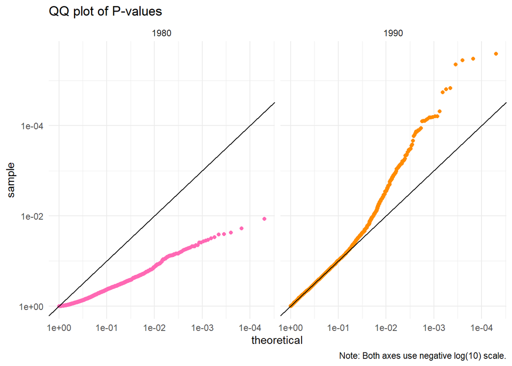

```r
tau_hat_results %>%
  ggplot(aes(sample = pval, colour = dataset)) +
  stat_qq(distribution = qunif)  +
  geom_abline(intercept = 0, slope = 1) +
  theme_minimal() +
  scale_x_continuous(trans=negative_log_trans(10)) +
  scale_y_continuous(trans=negative_log_trans(10)) +
  labs(title = "QQ plot of P-values",
       caption = "Note: Both axes use negative log(10) scale.") +
  facet_wrap(~dataset) +
  scale_colour_manual(values = colour_pair) +
  guides(colour = "none",
         fill = "none")
```